# LR_Attrition

Pinak Kapalay

February 28, 2019

Problem Statement : To study the following data, analyze it and predict which employee is likely to undergo Attrition and which not. Make the best possible model so that when applied to the future set of data, would generate acceptable results.

Solution : The above statement comes under the category of classification problem which can be solved using either of the Logistic Regression, Support Vector Machine, Decision Tree and Random Forest classification Algorithms.

The Logistic Regression Algorithm for the problem statement is as follows:

Comments: Reading the csv file.

```r
attr <- read.csv('C:/Users/KUGAAH/Documents/Attrition.csv',na.strings = c(""," ","?","NA","na"))
```

Comments: View the dataset.

```r
View(attr)
```

```r
str(attr)
```

```
## 'data.frame':    1470 obs. of  35 variables:
##  $ Age                     : int  41 49 37 33 27 32 59 30 38 36 ...
##  $ Attrition               : Factor w/ 2 levels "No","Yes": 2 1 2 1 1 1 1 1 1 1 ...
##  $ BusinessTravel          : Factor w/ 3 levels "Non-Travel","Travel_Frequently",..: 3 2 3 2 3 2 3 3 2 3 ...
##  $ DailyRate               : int  1102 279 1373 1392 591 1005 1324 1358 216 1299 ...
##  $ Department              : Factor w/ 3 levels "Human Resources",..: 3 2 2 2 2 2 2 2 2 2 ...
##  $ DistanceFromHome        : int  1 8 2 3 2 2 3 24 23 27 ...
##  $ Education               : int  2 1 2 4 1 2 3 1 3 3 ...
##  $ EducationField          : Factor w/ 6 levels "Human Resources",..: 2 2 5 2 4 2 4 2 2 4 ...
##  $ EmployeeCount           : int  1 1 1 1 1 1 1 1 1 1 ...
##  $ EmployeeNumber          : int  1 2 4 5 7 8 10 11 12 13 ...
##  $ EnvironmentSatisfaction : int  2 3 4 4 1 4 3 4 4 3 ...
##  $ Gender                  : Factor w/ 2 levels "Female","Male": 1 2 2 1 2 2 1 2 2 2 ...
##  $ HourlyRate              : int  94 61 92 56 40 79 81 67 44 94 ...
##  $ JobInvolvement          : int  3 2 2 3 3 3 4 3 2 3 ...
```

[output cut: 21 more lines]

```r
dim(attr)
```

```
## [1] 1470   35
```

Comments: Converting the following variables as factors to be used in the algorithm (Although, these could even be used as numeric values also).

```r
attr$Education <- as.factor(attr$Education)
attr$EnvironmentSatisfaction <- as.factor(attr$EnvironmentSatisfaction)
attr$JobInvolvement <- as.factor(attr$JobInvolvement)
attr$JobSatisfaction <- as.factor(attr$JobSatisfaction)
attr$PerformanceRating <- as.factor(attr$PerformanceRating)
attr$RelationshipSatisfaction <- as.factor(attr$RelationshipSatisfaction)
attr$WorkLifeBalance <- as.factor(attr$WorkLifeBalance)

str(attr)
```

```
## 'data.frame':    1470 obs. of  35 variables:
##  $ Age                     : int  41 49 37 33 27 32 59 30 38 36 ...
##  $ Attrition               : Factor w/ 2 levels "No","Yes": 2 1 2 1 1 1 1 1 1 1 ...
##  $ BusinessTravel          : Factor w/ 3 levels "Non-Travel","Travel_Frequently",..: 3 2 3 2 3 2 3 3 2 3 ...
##  $ DailyRate               : int  1102 279 1373 1392 591 1005 1324 1358 216 1299 ...
##  $ Department              : Factor w/ 3 levels "Human Resources",..: 3 2 2 2 2 2 2 2 2 2 ...
##  $ DistanceFromHome        : int  1 8 2 3 2 2 3 24 23 27 ...
##  $ Education               : Factor w/ 5 levels "1","2","3","4",..: 2 1 2 4 1 2 3 1 3 3 ...
##  $ EducationField          : Factor w/ 6 levels "Human Resources",..: 2 2 5 2 4 2 4 2 2 4 ...
##  $ EmployeeCount           : int  1 1 1 1 1 1 1 1 1 1 ...
##  $ EmployeeNumber          : int  1 2 4 5 7 8 10 11 12 13 ...
##  $ EnvironmentSatisfaction : Factor w/ 4 levels "1","2","3","4": 2 3 4 4 1 4 3 4 4 3 ...
##  $ Gender                  : Factor w/ 2 levels "Female","Male": 1 2 2 1 2 2 1 2 2 2 ...
##  $ HourlyRate              : int  94 61 92 56 40 79 81 67 44 94 ...
##  $ JobInvolvement          : Factor w/ 4 levels "1","2","3","4": 3 2 2 3 3 3 4 3 2 3 ...
```

[output cut: 21 more lines]

Comments: Forming new categorical dataset out of the original one for visual purposes.

```r
attr_cat <- attr[c(2,3,5,7,8,11,12,14,16,17,18,23,25,26,31)]
View(attr_cat)
str(attr_cat)
```

```
## 'data.frame':    1470 obs. of  15 variables:
##  $ Attrition               : Factor w/ 2 levels "No","Yes": 2 1 2 1 1 1 1 1 1 1 ...
##  $ BusinessTravel          : Factor w/ 3 levels "Non-Travel","Travel_Frequently",..: 3 2 3 2 3 2 3 3 2 3 ...
##  $ Department              : Factor w/ 3 levels "Human Resources",..: 3 2 2 2 2 2 2 2 2 2 ...
##  $ Education               : Factor w/ 5 levels "1","2","3","4",..: 2 1 2 4 1 2 3 1 3 3 ...
##  $ EducationField          : Factor w/ 6 levels "Human Resources",..: 2 2 5 2 4 2 4 2 2 4 ...
##  $ EnvironmentSatisfaction : Factor w/ 4 levels "1","2","3","4": 2 3 4 4 1 4 3 4 4 3 ...
##  $ Gender                  : Factor w/ 2 levels "Female","Male": 1 2 2 1 2 2 1 2 2 2 ...
##  $ JobInvolvement          : Factor w/ 4 levels "1","2","3","4": 3 2 2 3 3 3 4 3 2 3 ...
##  $ JobRole                 : Factor w/ 9 levels "Healthcare Representative",..: 8 7 3 7 3 3 3 3 5 1 ...
##  $ JobSatisfaction         : Factor w/ 4 levels "1","2","3","4": 4 2 3 3 2 4 1 3 3 3 ...
##  $ MaritalStatus           : Factor w/ 3 levels "Divorced","Married",..: 3 2 3 2 2 3 2 1 3 2 ...
##  $ OverTime                : Factor w/ 2 levels "No","Yes": 2 1 2 2 1 1 2 1 1 1 ...
##  $ PerformanceRating       : Factor w/ 2 levels "3","4": 1 2 1 1 1 1 2 2 2 1 ...
##  $ RelationshipSatisfaction: Factor w/ 4 levels "1","2","3","4": 1 4 2 3 4 3 1 2 2 2 ...
##  $ WorkLifeBalance         : Factor w/ 4 levels "1","2","3","4": 1 3 3 3 3 2 2 3 3 2 ...
```

Comments: Figuring out the total number of employees undergone Attrition out of the total strength using a pie.

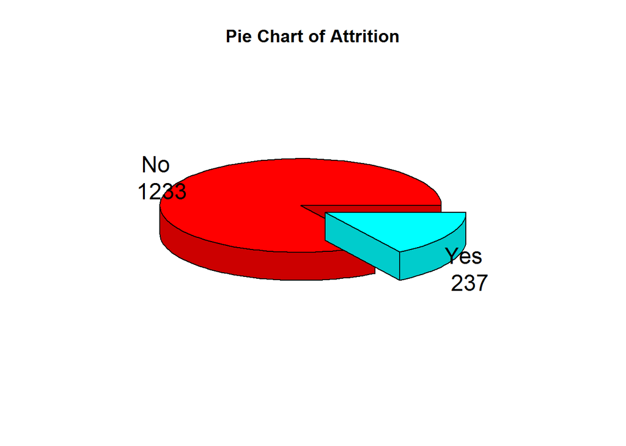

```r
library(plotrix)
mytable <- table(attr_cat$Attrition)
lbls <- paste(names(mytable), "\n", mytable)
pie3D(mytable, labels = lbls,explode = 0.1, main="Pie Chart of Attrition")
```

Comments: Employing Bar charts for a proper visualization of the data.

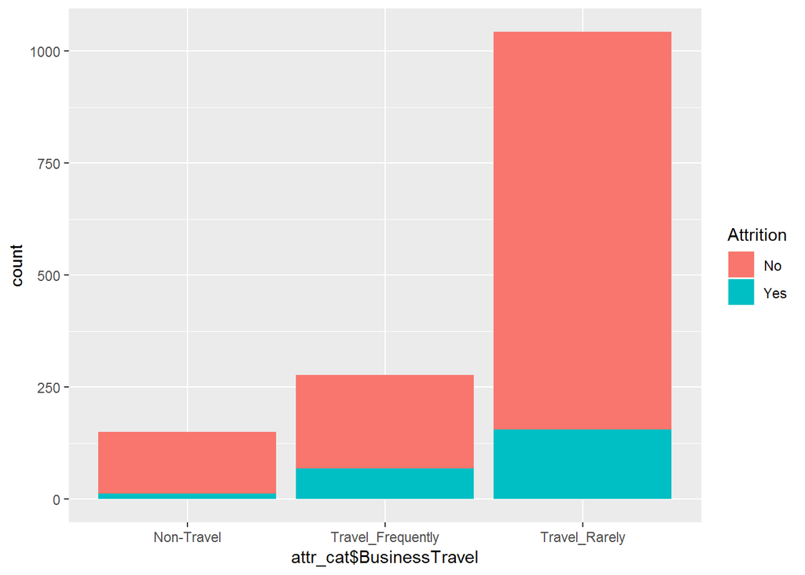

```r
library(ggplot2)
ggplot(data = attr_cat) + geom_bar(aes(x = attr_cat$BusinessTravel, fill = Attrition))
```

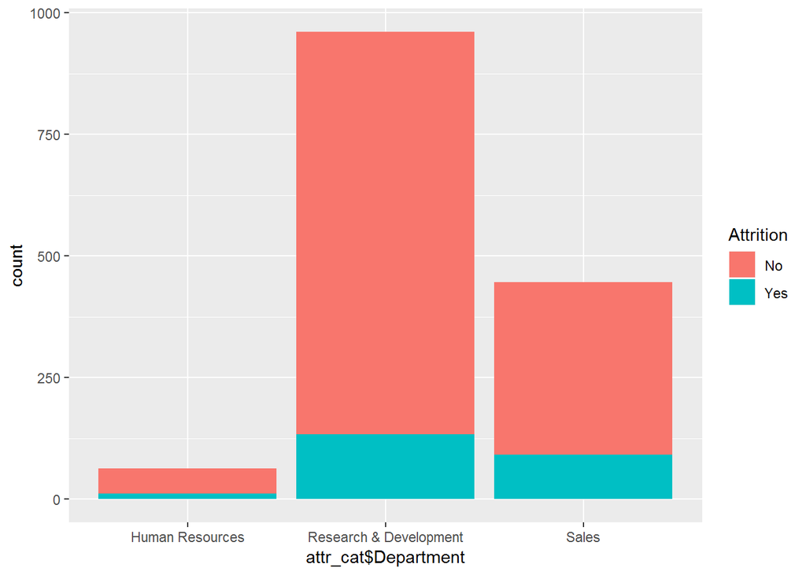

```r
ggplot(data = attr_cat) + geom_bar(aes(x = attr_cat$Department, fill = Attrition))
```

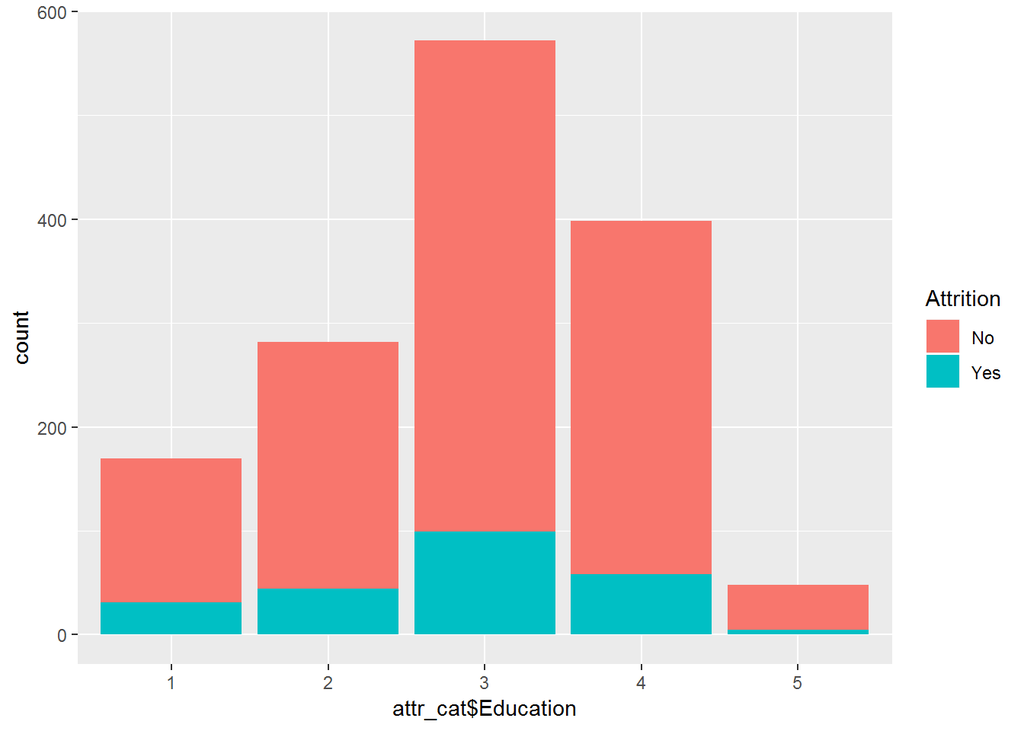

```r
ggplot(data = attr_cat) + geom_bar(aes(x = attr_cat$Education, fill = Attrition))
```

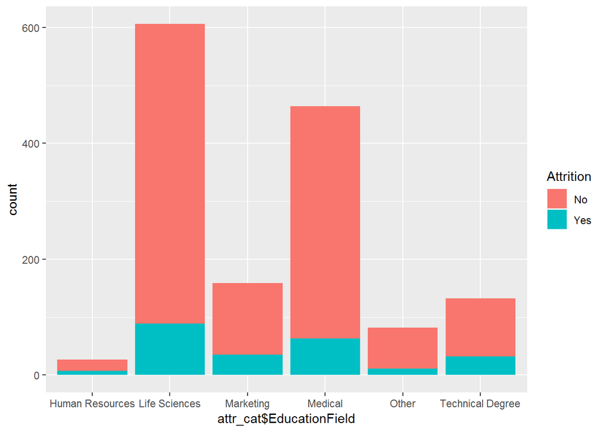

```r
ggplot(data = attr_cat) + geom_bar(aes(x = attr_cat$EducationField, fill = Attrition))
```

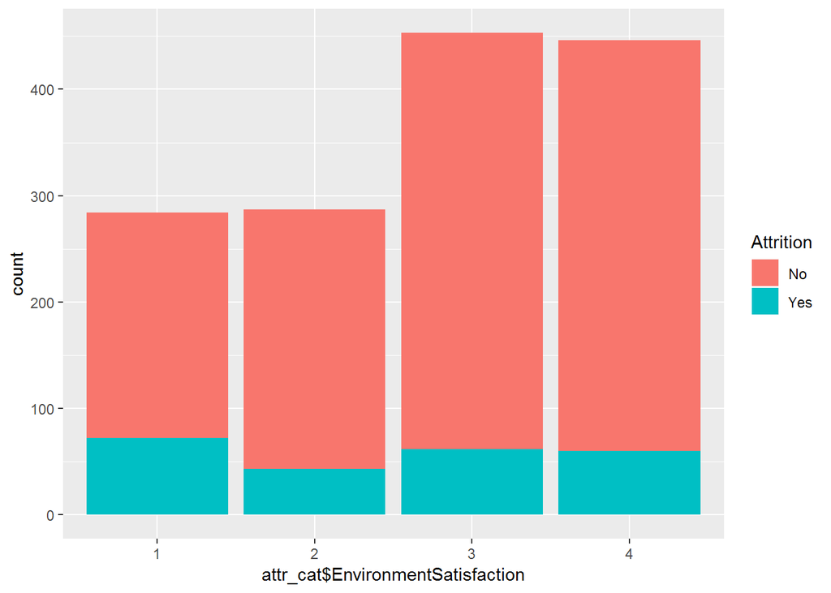

```r
ggplot(data = attr_cat) + geom_bar(aes(x = attr_cat$EnvironmentSatisfaction, fill = Attrition))
```

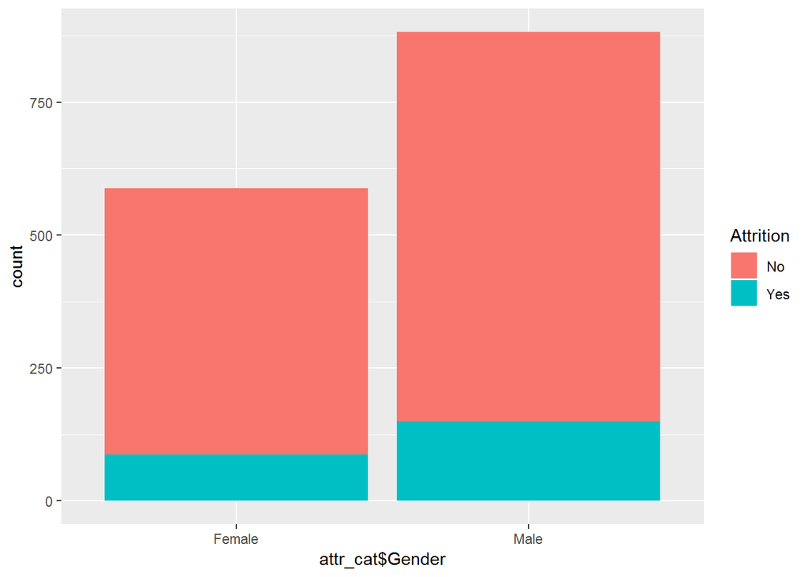

```r
ggplot(data = attr_cat) + geom_bar(aes(x = attr_cat$Gender, fill = Attrition))
```

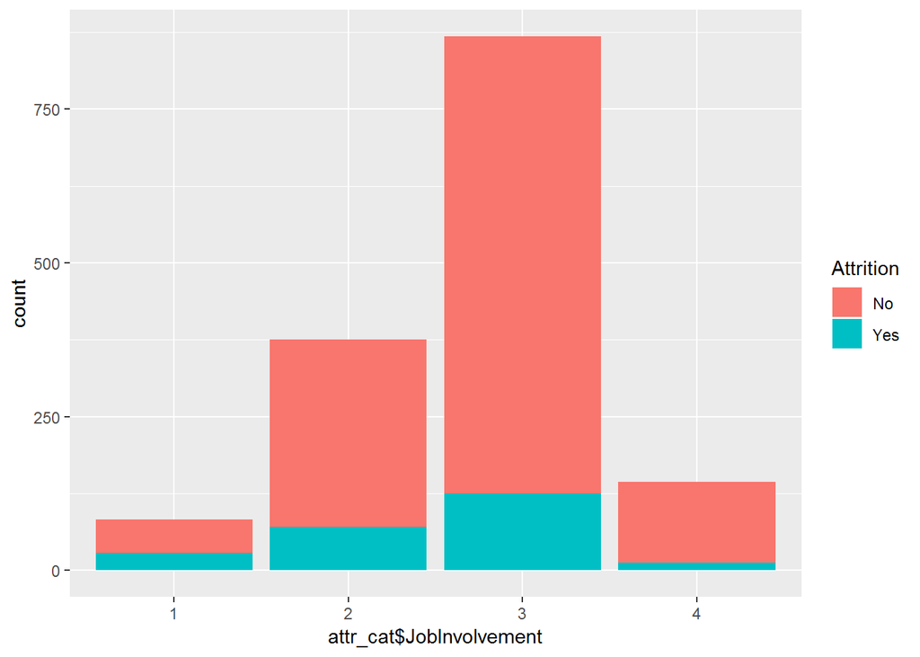

```r
ggplot(data = attr_cat) + geom_bar(aes(x = attr_cat$JobInvolvement, fill = Attrition))
```

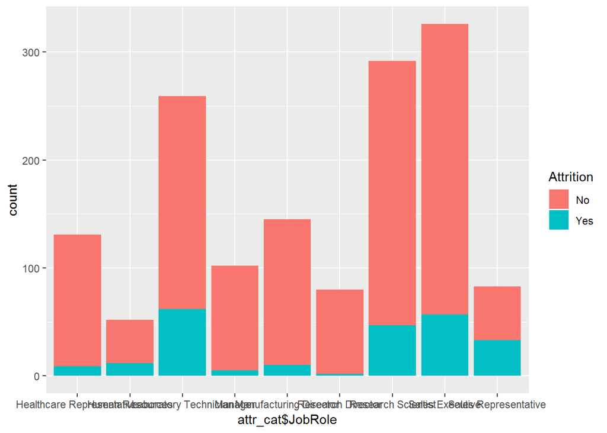

```r
ggplot(data = attr_cat) + geom_bar(aes(x = attr_cat$JobRole, fill = Attrition))
```

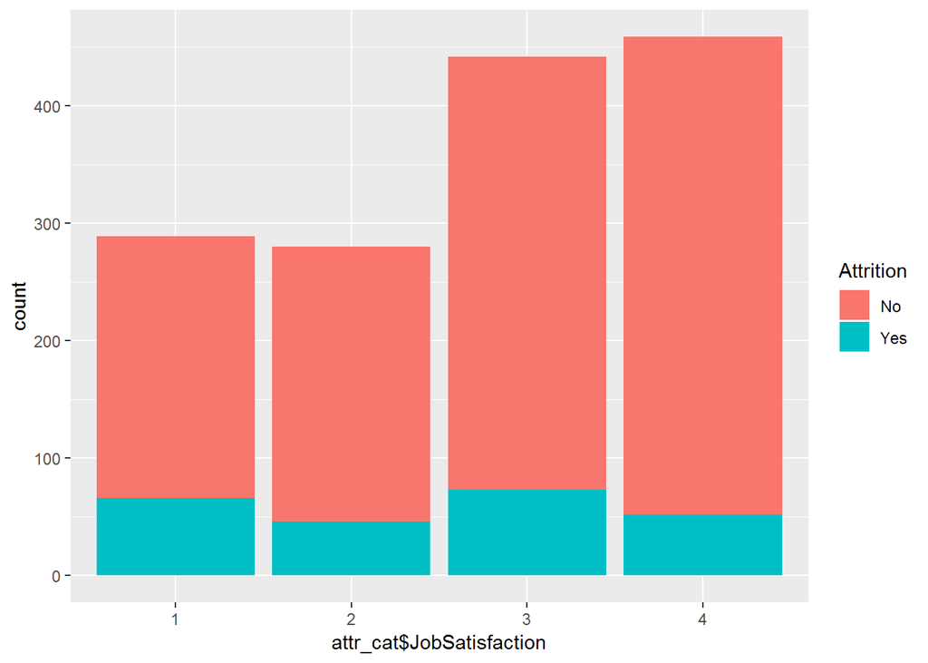

```r
ggplot(data = attr_cat) + geom_bar(aes(x = attr_cat$JobSatisfaction, fill = Attrition))
```

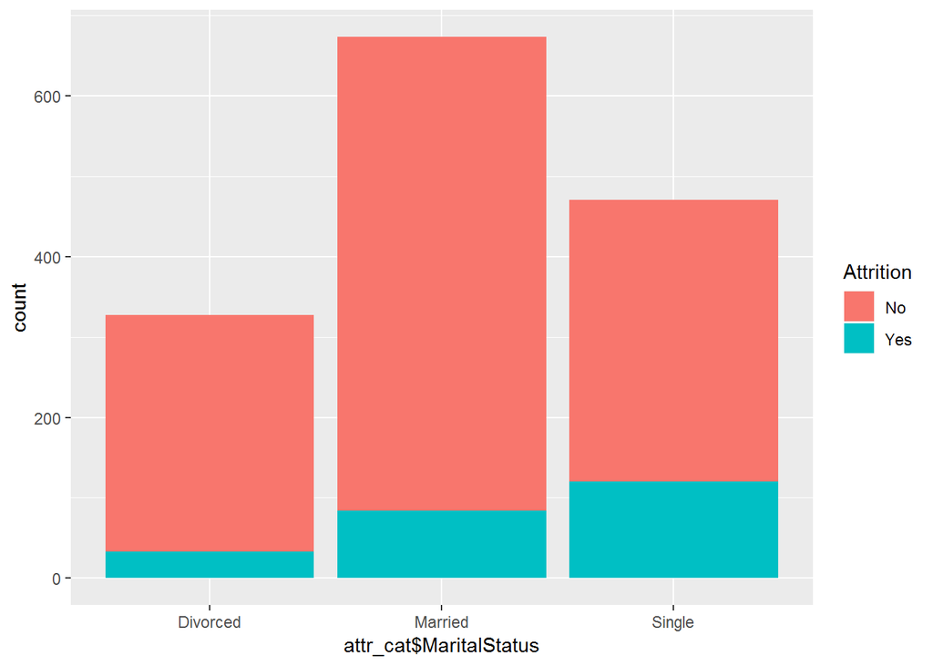

```r
ggplot(data = attr_cat) + geom_bar(aes(x = attr_cat$MaritalStatus, fill = Attrition))
```

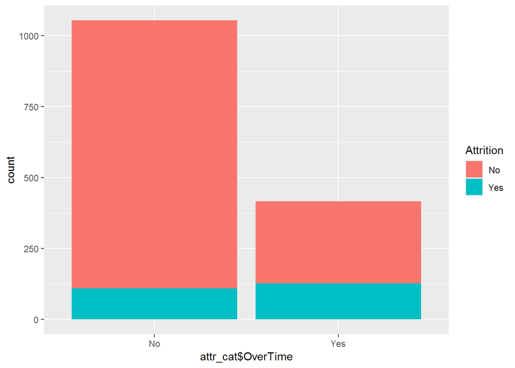

```r
ggplot(data = attr_cat) + geom_bar(aes(x = attr_cat$OverTime, fill = Attrition))
```

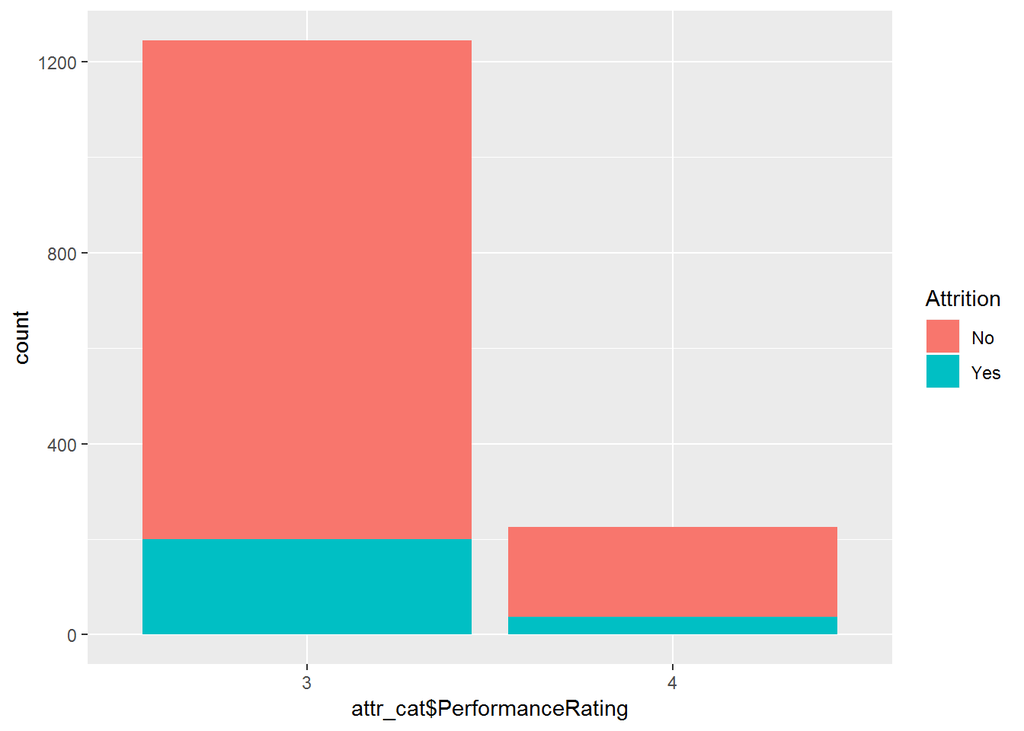

```r
ggplot(data = attr_cat) + geom_bar(aes(x = attr_cat$PerformanceRating, fill = Attrition))
```

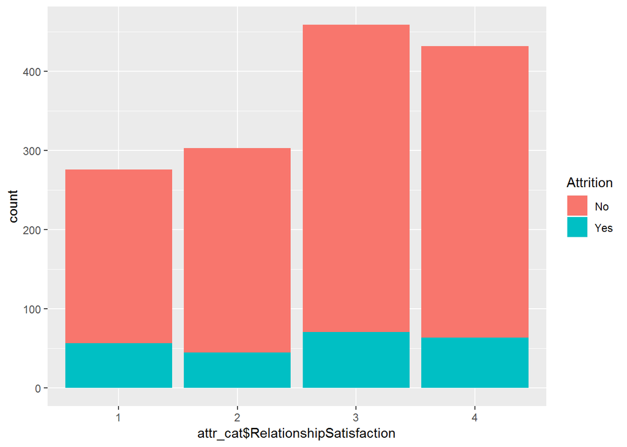

```r
ggplot(data = attr_cat) + geom_bar(aes(x = attr_cat$RelationshipSatisfaction, fill = Attrition))
```

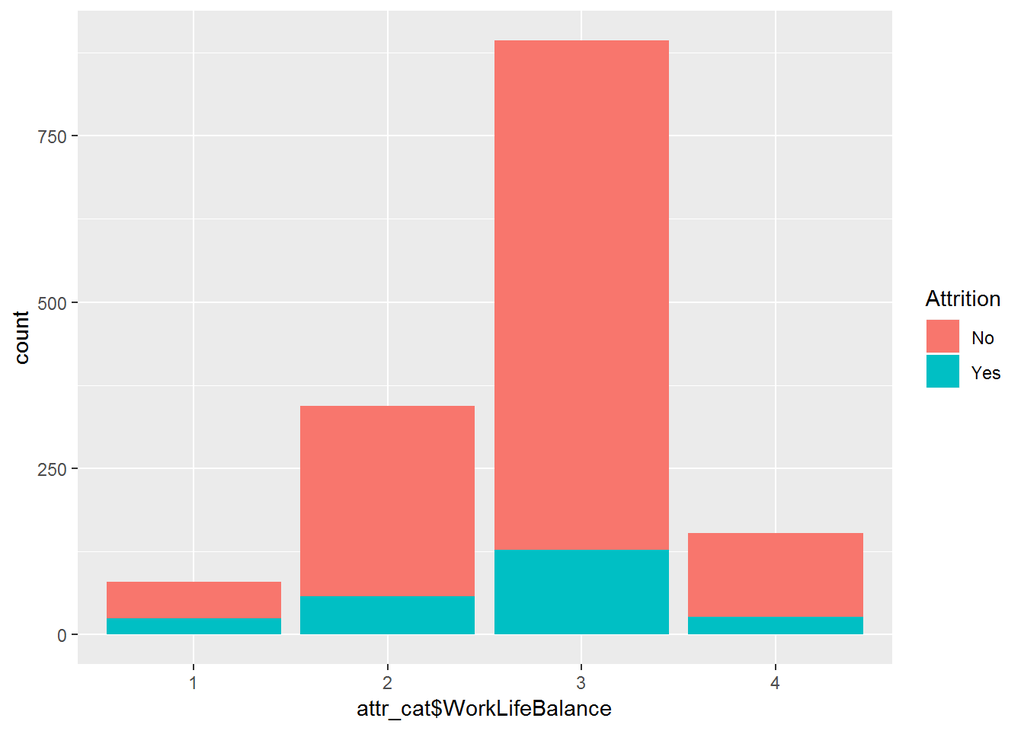

```r
ggplot(data = attr_cat) + geom_bar(aes(x = attr_cat$WorkLifeBalance, fill = Attrition))
```

Comments: Converting the two class variables to binary variables. 0 is assigned to Attrition and 1 to No - Attrition.

```r
apply(is.na(attr),2,sum)   # CHecking for the NAs.
```

```
##                      Age                Attrition           BusinessTravel
##                        0                        0                        0
##                DailyRate               Department         DistanceFromHome
##                        0                        0                        0
##                Education           EducationField            EmployeeCount
##                        0                        0                        0
##           EmployeeNumber  EnvironmentSatisfaction                   Gender
##                        0                        0                        0
##               HourlyRate           JobInvolvement                 JobLevel
##                        0                        0                        0
##                  JobRole          JobSatisfaction            MaritalStatus
##                        0                        0                        0
##            MonthlyIncome              MonthlyRate       NumCompaniesWorked
##                        0                        0                        0
##                   Over18                 OverTime        PercentSalaryHike
##                        0                        0                        0
##        PerformanceRating RelationshipSatisfaction            StandardHours
##                        0                        0                        0
##         StockOptionLevel        TotalWorkingYears    TrainingTimesLastYear
##                        0                        0                        0
##          WorkLifeBalance           YearsAtCompany       YearsInCurrentRole
##                        0                        0                        0
##  YearsSinceLastPromotion     YearsWithCurrManager
##                        0                        0
```

```r
attr$Attrition <- ifelse(attr$Attrition == 'Yes',0,1)

attr$Gender <- ifelse(attr$Gender == 'Male',1,0)

attr$OverTime <- ifelse(attr$OverTime == 'No',0,1)

View(attr)
```

Comments: Taking help of correlation plot to find out the mutual correlation between the numeric variables.

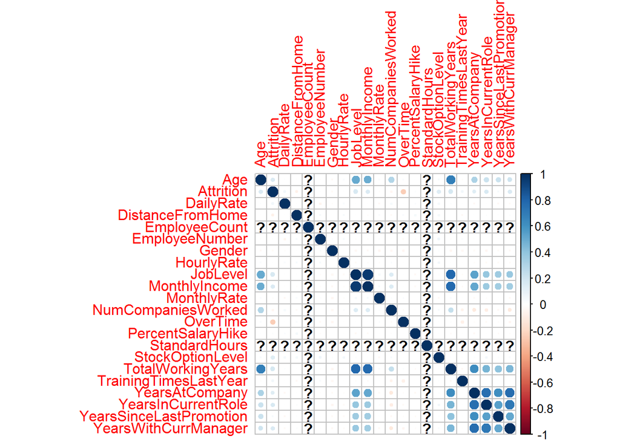

```r
library(corrplot)
attr_num <- attr[sapply(attr,is.numeric)]
attr_cor <- cor(attr_num)
View(attr_cor)
corrplot(attr_cor)
```

Comments : Converting the n-class categorical variables to dummies for easier evaluation (at, they get converted into binary ones) and check the new dimensions.

```r
library(fastDummies)
attr <- dummy_cols(attr, select_columns = c('BusinessTravel','Department','Education','EducationField',
                                          'EnvironmentSatisfaction','JobInvolvement','JobRole','JobSatisfaction',
                                            'MaritalStatus','PerformanceRating','RelationshipSatisfaction',
                                            'WorkLifeBalance'))
```

```r
View(attr)
```

```r
dim(attr)
```

```
## [1] 1470   86
```

Comments: Removing all the variables previously converted into dummies (As they are no more required).

```r
attr <- attr[c(-3,-5,-7,-8,-9,-10,-11,-14,-15,-16,-17,-18,-22,-25,-26,-31)]

str(attr)
```

```
## 'data.frame':    1470 obs. of  70 variables:
##  $ Age                              : int  41 49 37 33 27 32 59 30 38 36 ...
##  $ Attrition                        : num  0 1 0 1 1 1 1 1 1 1 ...
##  $ DailyRate                        : int  1102 279 1373 1392 591 1005 1324 1358 216 1299 ...
##  $ DistanceFromHome                 : int  1 8 2 3 2 2 3 24 23 27 ...
##  $ Gender                           : num  0 1 1 0 1 1 0 1 1 1 ...
##  $ HourlyRate                       : int  94 61 92 56 40 79 81 67 44 94 ...
##  $ MonthlyIncome                    : int  5993 5130 2090 2909 3468 3068 2670 2693 9526 5237 ...
##  $ MonthlyRate                      : int  19479 24907 2396 23159 16632 11864 9964 13335 8787 16577 ...
##  $ NumCompaniesWorked               : int  8 1 6 1 9 0 4 1 0 6 ...
##  $ OverTime                         : num  1 0 1 1 0 0 1 0 0 0 ...
##  $ PercentSalaryHike                : int  11 23 15 11 12 13 20 22 21 13 ...
##  $ StandardHours                    : int  80 80 80 80 80 80 80 80 80 80 ...
##  $ StockOptionLevel                 : int  0 1 0 0 1 0 3 1 0 2 ...
##  $ TotalWorkingYears                : int  8 10 7 8 6 8 12 1 10 17 ...
```

[output cut: 56 more lines]

Comments: Checking for outliers using the boxplot (All the variables with outliers are marked in the code itself).

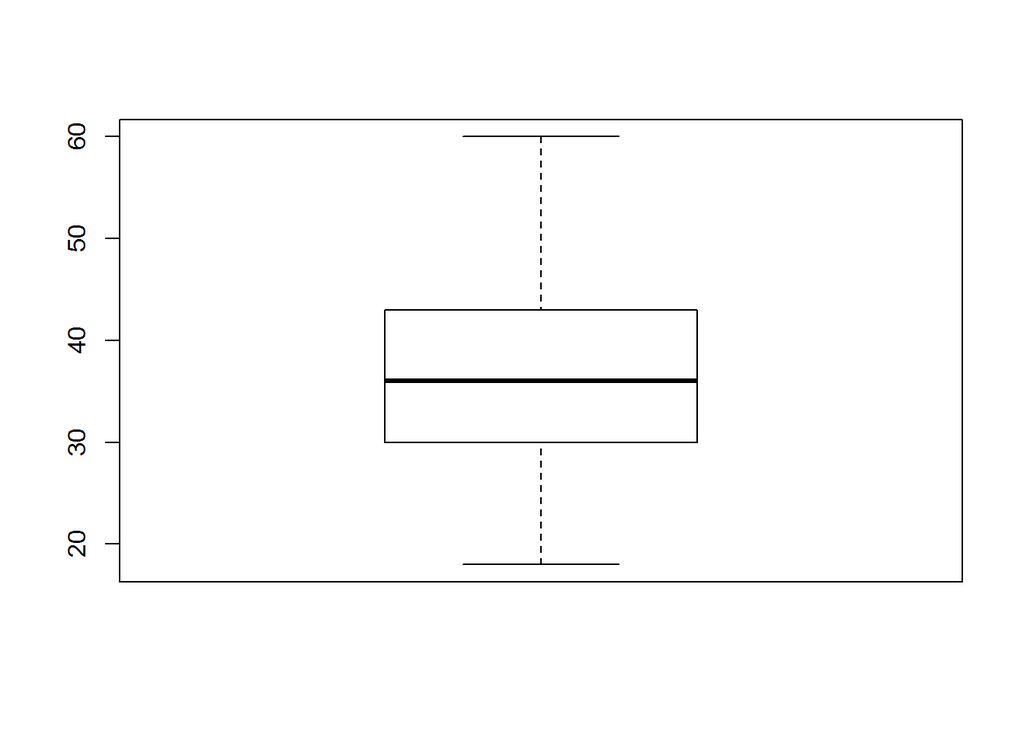

```r
library(ggplot2)

boxplot(attr$Age)
```

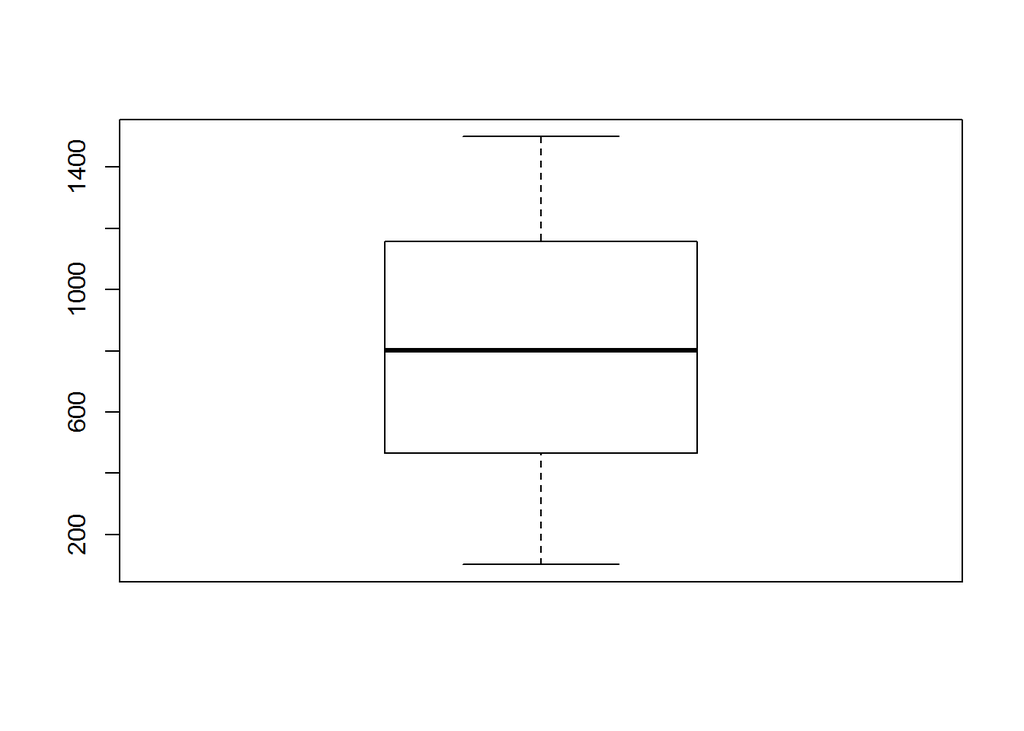

```r
boxplot(attr$DailyRate)
```

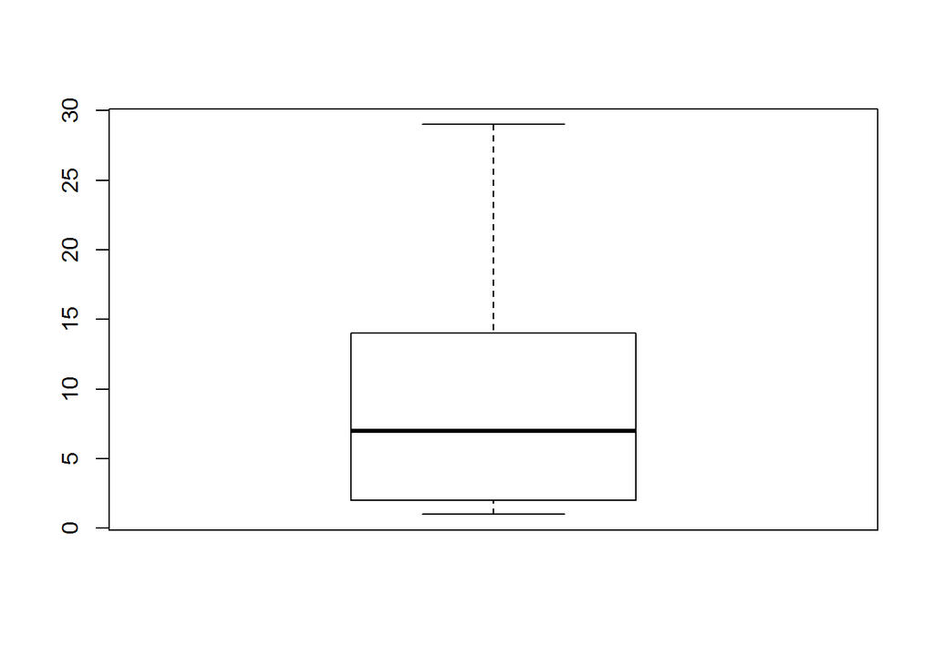

```r
boxplot(attr$DistanceFromHome)
```

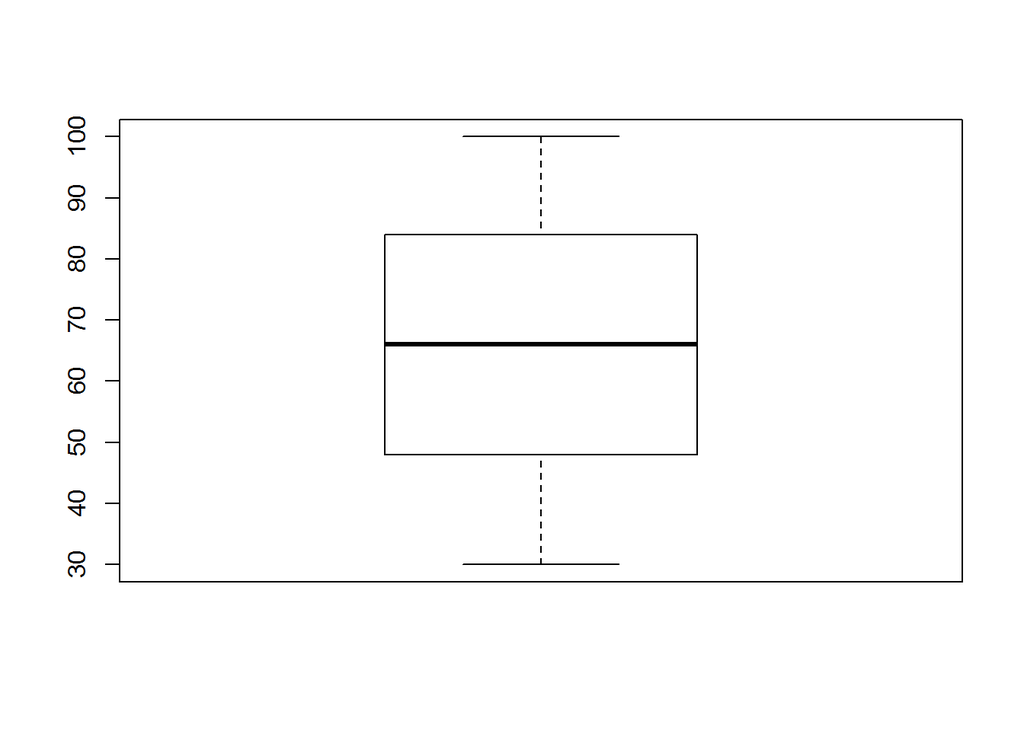

```r
boxplot(attr$HourlyRate)
```

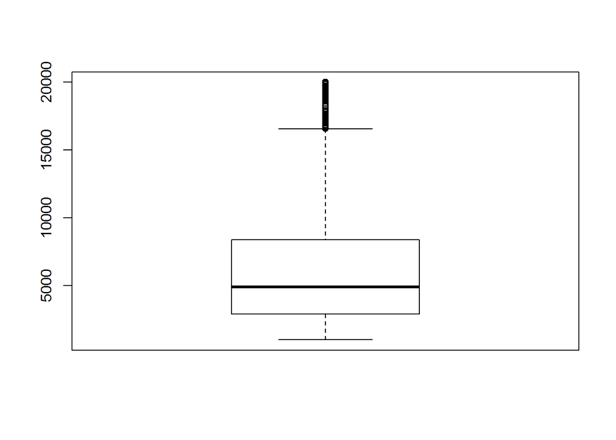

```r
boxplot(attr$MonthlyIncome)               # Outliers Detected.
```

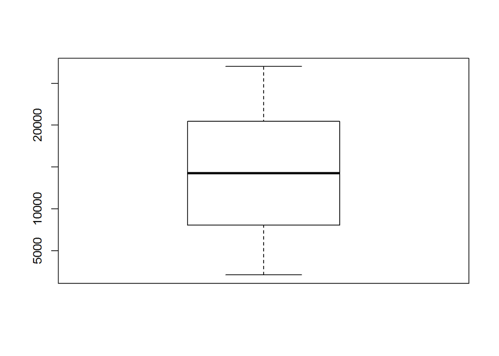

```r
boxplot(attr$MonthlyRate)
```

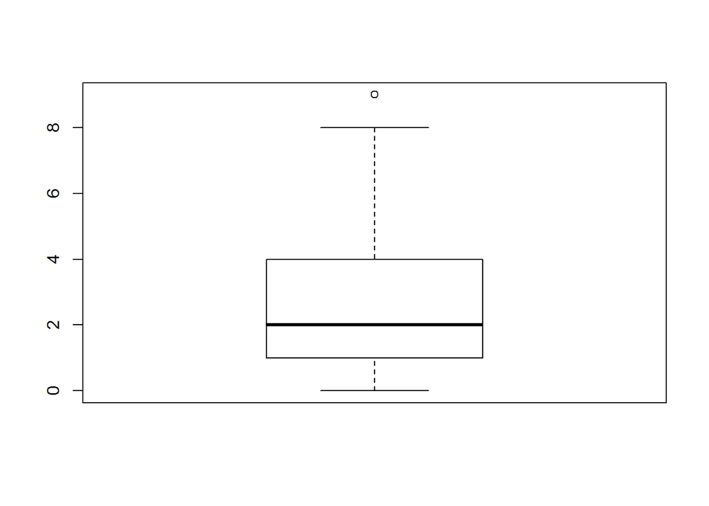

```r
boxplot(attr$NumCompaniesWorked)          # Outliers detected.
```

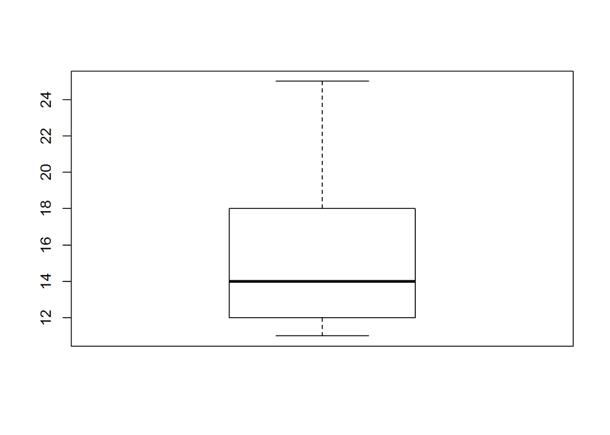

```r
boxplot(attr$PercentSalaryHike)
```

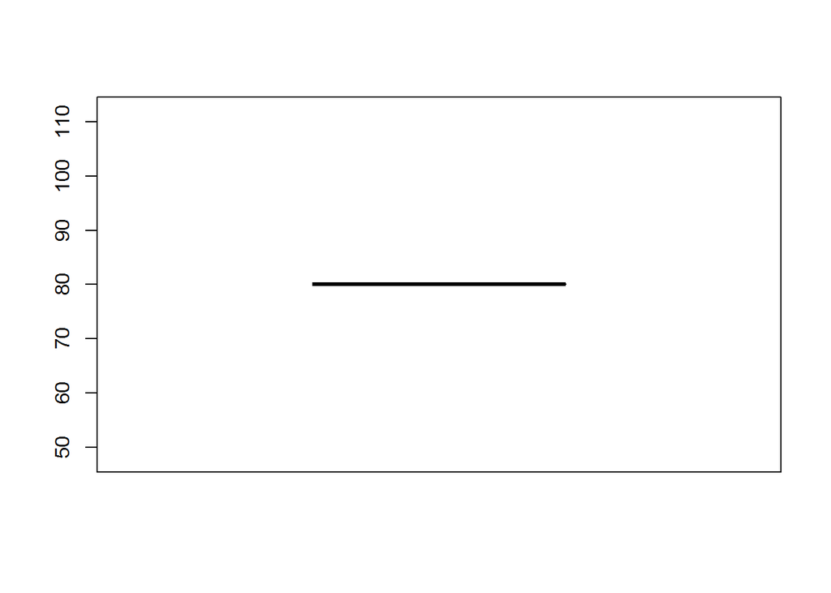

```r
boxplot(attr$StandardHours)
```

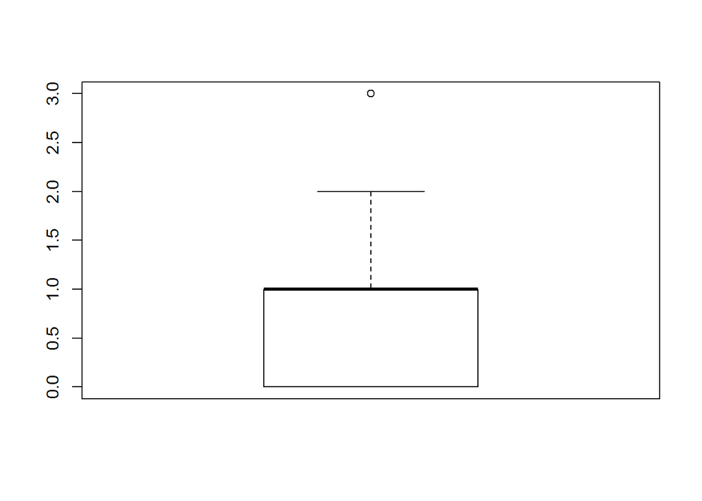

```r
boxplot(attr$StockOptionLevel)            # Outliers Detected.
```

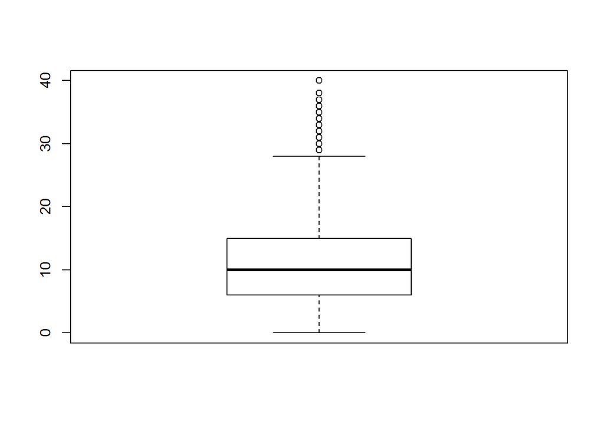

```r
boxplot(attr$TotalWorkingYears)           # Outliers Detected.
```

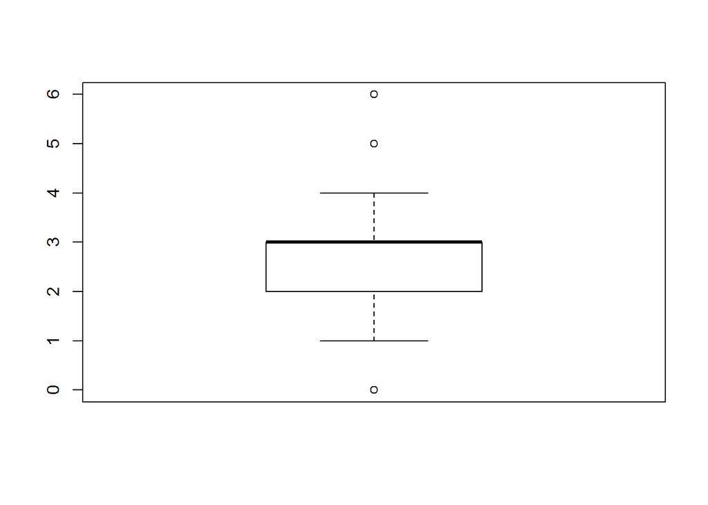

```r
boxplot(attr$TrainingTimesLastYear)       # Outliers Detected.
```

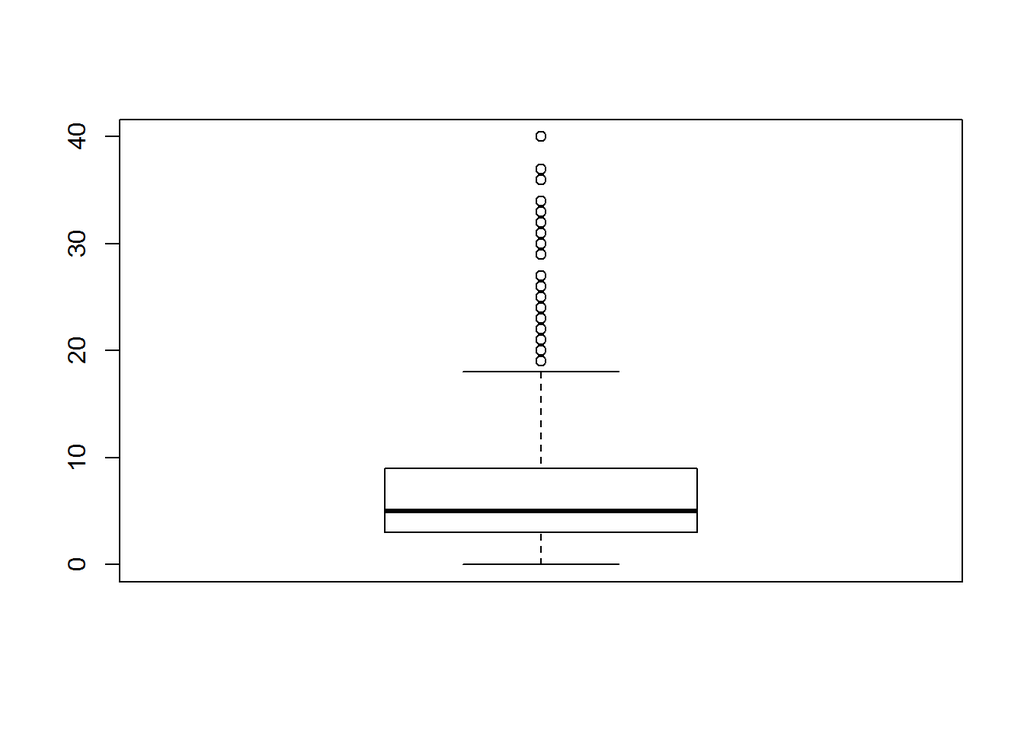

```r
boxplot(attr$YearsAtCompany)              # Outliers Detected.
```

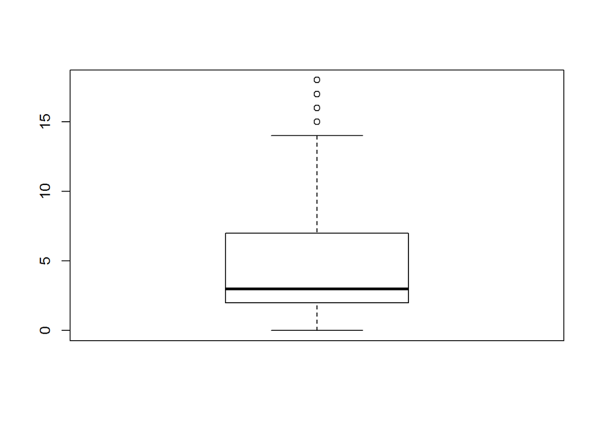

```r
boxplot(attr$YearsInCurrentRole)          # Outliers Detected.
```

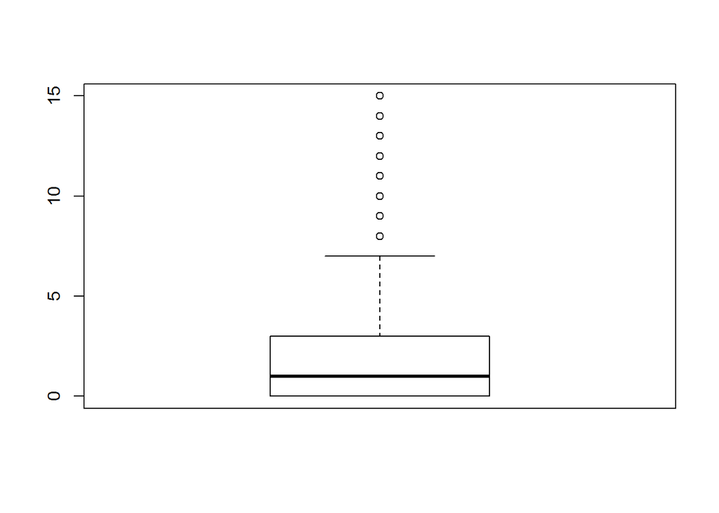

```r
boxplot(attr$YearsSinceLastPromotion)     # Outliers Detected.
```

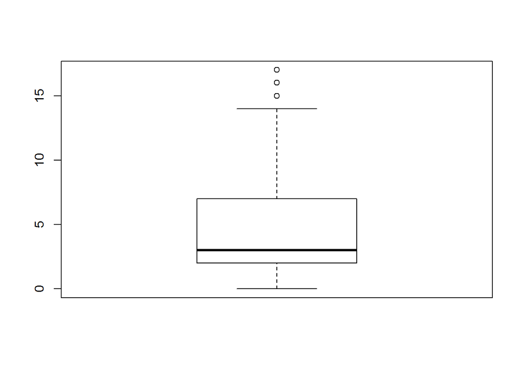

```r
boxplot(attr$YearsWithCurrManager)        # Outliers Detected.
```

Comments: Finding the numbers of the previously detected outliers and their upper and lower cutoff for each variable.

```r
out_std_check = function(x,f){
  q1 = quantile(x,0.25, na.rm = TRUE)
  q3 = quantile(x,0.75, na.rm = TRUE)
  iqr = q3-q1
  lc=q1-f*iqr
  uc=q3+f*iqr
  n=sum(x>uc | x<lc)
  #return n
  val=list(num=n,lower_cutoff=lc,upper_cutoff=uc)
  return(val)
}

out_std_check(attr$MonthlyIncome,1.5)
```

```
## $num
## [1] 114
##
## $lower_cutoff
##   25%
## -5291
##
## $upper_cutoff
##   75%
## 16581
```

```r
out_std_check(attr$NumCompaniesWorked,1.5)
```

```
## $num
## [1] 52
##
## $lower_cutoff
##  25%
## -3.5
##
## $upper_cutoff
## 75%
## 8.5
```

```r
out_std_check(attr$StockOptionLevel,1.5)
```

```
## $num
## [1] 85
##
## $lower_cutoff
##  25%
## -1.5
##
## $upper_cutoff
## 75%
## 2.5
```

```r
out_std_check(attr$TotalWorkingYears,1.5)
```

```
## $num
## [1] 63
##
## $lower_cutoff
##  25%
## -7.5
##
## $upper_cutoff
##  75%
## 28.5
```

```r
out_std_check(attr$TrainingTimesLastYear,1.5)
```

```
## $num
## [1] 238
##
## $lower_cutoff
## 25%
## 0.5
##
## $upper_cutoff
## 75%
## 4.5
```

```r
out_std_check(attr$YearsAtCompany,1.5)
```

```
## $num
## [1] 104
##
## $lower_cutoff
## 25%
##  -6
##
## $upper_cutoff
## 75%
##  18
```

```r
out_std_check(attr$YearsInCurrentRole,1.5)
```

```
## $num
## [1] 21
##
## $lower_cutoff
##  25%
## -5.5
##
## $upper_cutoff
##  75%
## 14.5
```

```r
out_std_check(attr$YearsSinceLastPromotion,1.5)
```

```
## $num
## [1] 107
##
## $lower_cutoff
##  25%
## -4.5
##
## $upper_cutoff
## 75%
## 7.5
```

```r
out_std_check(attr$YearsWithCurrManager,1.5)
```

```
## $num
## [1] 14
##
## $lower_cutoff
##  25%
## -5.5
##
## $upper_cutoff
##  75%
## 14.5
```

Comments: Capping th outliers by imputing them with the upper and lower cut-off in order to make the data distribution fair i.e remove skewness if any.

```r
attr_out_impute <- function(x,f){

  q1 = quantile(x,0.25, na.rm = TRUE)
  q3 = quantile(x,0.75, na.rm = TRUE)
  iqr = q3-q1
  lc = q1-f*iqr
  uc = q3+f*iqr

  for (j in 1:length(x)) {
    if(x[j]<lc)
    {x[j] <- lc}
    else if(x[j]>uc)
    {x[j] <- uc}
    else
    {}
    }
   return(x)
}


attr$MonthlyIncome <- attr_out_impute(attr$MonthlyIncome,1.5)
out_std_check(attr$MonthlyIncome,1.5)
```

```
## $num
## [1] 0
##
## $lower_cutoff
##   25%
## -5291
##
## $upper_cutoff
##   75%
## 16581
```

```r
attr$NumCompaniesWorked <- attr_out_impute(attr$NumCompaniesWorked,1.5)
out_std_check(attr$NumCompaniesWorked,1.5)
```

```
## $num
## [1] 0
##
## $lower_cutoff
##  25%
## -3.5
##
## $upper_cutoff
## 75%
## 8.5
```

```r
attr$StockOptionLevel <- attr_out_impute(attr$StockOptionLevel,1.5)
out_std_check(attr$StockOptionLevel,1.5)
```

```
## $num
## [1] 0
##
## $lower_cutoff
##  25%
## -1.5
##
## $upper_cutoff
## 75%
## 2.5
```

```r
attr$TotalWorkingYears <- attr_out_impute(attr$TotalWorkingYears,1.5)
out_std_check(attr$TotalWorkingYears,1.5)
```

```
## $num
## [1] 0
##
## $lower_cutoff
##  25%
## -7.5
##
## $upper_cutoff
##  75%
## 28.5
```

```r
attr$TrainingTimesLastYear <- attr_out_impute(attr$TrainingTimesLastYear,1.5)
out_std_check(attr$TrainingTimesLastYear,1.5)
```

```
## $num
## [1] 0
##
## $lower_cutoff
## 25%
## 0.5
##
## $upper_cutoff
## 75%
## 4.5
```

```r
attr$YearsAtCompany <- attr_out_impute(attr$YearsAtCompany,1.5)
out_std_check(attr$YearsAtCompany,1.5)
```

```
## $num
## [1] 0
##
## $lower_cutoff
## 25%
##  -6
##
## $upper_cutoff
## 75%
##  18
```

```r
attr$YearsInCurrentRole <- attr_out_impute(attr$YearsInCurrentRole,1.5)
out_std_check(attr$YearsInCurrentRole,1.5)
```

```
## $num
## [1] 0
##
## $lower_cutoff
##  25%
## -5.5
##
## $upper_cutoff
##  75%
## 14.5
```

```r
attr$YearsSinceLastPromotion <- attr_out_impute(attr$YearsSinceLastPromotion,1.5)
out_std_check(attr$YearsSinceLastPromotion,1.5)
```

```
## $num
## [1] 0
##
## $lower_cutoff
##  25%
## -4.5
##
## $upper_cutoff
## 75%
## 7.5
```

```r
attr$YearsWithCurrManager <- attr_out_impute(attr$YearsWithCurrManager,1.5)
out_std_check(attr$YearsWithCurrManager,1.5)
```

```
## $num
## [1] 0
##
## $lower_cutoff
##  25%
## -5.5
##
## $upper_cutoff
##  75%
## 14.5
```

```r
attr$Age <- (attr$Age - min(attr$Age))/(max(attr$Age)-min(attr$Age))

attr$DailyRate <- (attr$DailyRate - min(attr$DailyRate))/(max(attr$DailyRate) - min(attr$DailyRate))

attr$DistanceFromHome <- (attr$DistanceFromHome - min(attr$DistanceFromHome))/(max(attr$DistanceFromHome) - min(attr$DistanceFromHome))

attr$HourlyRate <- (attr$HourlyRate - min(attr$HourlyRate))/(max(attr$HourlyRate)-min(attr$HourlyRate))

attr$MonthlyIncome <- (attr$MonthlyIncome - min(attr$MonthlyIncome))/(max(attr$MonthlyIncome)-min(attr$MonthlyIncome))

attr$MonthlyRate <- (attr$MonthlyRate - min(attr$MonthlyRate))/(max(attr$MonthlyRate)-min(attr$MonthlyRate))

attr$NumCompaniesWorked <- (attr$NumCompaniesWorked - min(attr$NumCompaniesWorked))/(max(attr$NumCompaniesWorked)-min(attr$NumCompaniesWorked))

attr$PercentSalaryHike <- (attr$PercentSalaryHike - min(attr$PercentSalaryHike))/(max(attr$PercentSalaryHike)-min(attr$PercentSalaryHike))

attr$StockOptionLevel <- (attr$StockOptionLevel - min(attr$StockOptionLevel))/(max(attr$StockOptionLevel)-min(attr$StockOptionLevel))

attr$TotalWorkingYears <- (attr$TotalWorkingYears - min(attr$TotalWorkingYears))/(max(attr$TotalWorkingYears)-min(attr$TotalWorkingYears))

attr$TrainingTimesLastYear <- (attr$TrainingTimesLastYear - min(attr$TrainingTimesLastYear))/(max(attr$TrainingTimesLastYear)-min(attr$TrainingTimesLastYear))

attr$YearsAtCompany <- (attr$YearsAtCompany - min(attr$YearsAtCompany))/(max(attr$YearsAtCompany)-min(attr$YearsAtCompany))

attr$YearsInCurrentRole <- (attr$YearsInCurrentRole - min(attr$YearsInCurrentRole))/(max(attr$YearsInCurrentRole)-min(attr$YearsInCurrentRole))

attr$YearsSinceLastPromotion <- (attr$YearsSinceLastPromotion - min(attr$YearsSinceLastPromotion))/(max(attr$YearsSinceLastPromotion)-min(attr$YearsSinceLastPromotion))

attr$YearsWithCurrManager <- (attr$YearsWithCurrManager - min(attr$YearsWithCurrManager))/(max(attr$YearsWithCurrManager)-min(attr$YearsWithCurrManager))
```

Comment: Removing an unnecessary variable.

```r
attr <- attr[-12]

View(attr)
```

Comments: Renaming all the variables according to the acceptable nomenclature terms for the R Programming.

```r
colnames(attr)[21] <- "BusinessTravel_Non_Travel"
colnames(attr)[23] <- "Department_Research_Development"
colnames(attr)[24] <- "Department_Human_Resources"
colnames(attr)[30] <- "EducationField_Life_Sciences"
colnames(attr)[34] <- "EducationField_Technical_Degree"
colnames(attr)[35] <- "EducationField_Human_Resources"
colnames(attr)[44] <- "JobRole_Sales_Executive"
colnames(attr)[45] <- "JobRole_Research_Scientist"
colnames(attr)[46] <- "JobRole_Laboratory_Technician"
colnames(attr)[47] <- "JobRole_Manufacturing_Director"
colnames(attr)[48] <- "JobRole_Healthcare_Representative"
colnames(attr)[50] <- "JobRole_Sales_Representative"
colnames(attr)[51] <- "JobRole_Research_Director"
colnames(attr)[52] <- "JobRole_Human_Resources"
```

Comments: Train - Test Split.

```r
set.seed(18)
s <- sample(1:nrow(attr),0.8*nrow(attr))
train <- attr[s,]
test <- attr[-s,]

View(train)

View(test)
```

Comments: Starting the modelling procedure. (glm stands for Generalised Linear Model and Binomial suggests that, the target variable is a Binary variable and that the Regression needs to be a classification one).

```r
library(MASS)

mod_1 <- glm(Attrition~.,data = train, family = 'binomial')
summary(mod_1)
```

```
##
## Call:
## glm(formula = Attrition ~ ., family = "binomial", data = train)
##
## Deviance Residuals:
##     Min       1Q   Median       3Q      Max
## -3.7971   0.0784   0.2300   0.4479   1.8573
##
## Coefficients: (12 not defined because of singularities)
##                                     Estimate Std. Error z value Pr(>|z|)
## (Intercept)                        -1.071861   1.347355  -0.796 0.426305
## Age                                 1.321820   0.679576   1.945 0.051767
## DailyRate                           0.324723   0.362637   0.895 0.370546
## DistanceFromHome                   -1.107414   0.367690  -3.012 0.002597
## Gender                             -0.411878   0.220288  -1.870 0.061522
## HourlyRate                          0.003936   0.358845   0.011 0.991249
## MonthlyIncome                      -0.472043   1.175691  -0.402 0.688050
## MonthlyRate                        -0.111575   0.367967  -0.303 0.761723
## NumCompaniesWorked                 -1.797757   0.397905  -4.518 6.24e-06
## OverTime                           -2.072300   0.232162  -8.926  < 2e-16
## PercentSalaryHike                   0.512823   0.648083   0.791 0.428774
## StockOptionLevel                    0.715574   0.520106   1.376 0.168876
## TotalWorkingYears                   1.666028   0.979782   1.700 0.089054
## TrainingTimesLastYear               0.524589   0.410466   1.278 0.201238
## YearsAtCompany                     -1.060314   1.142285  -0.928 0.353284
## YearsInCurrentRole                  2.076550   0.909909   2.282 0.022480
## YearsSinceLastPromotion            -1.288701   0.453456  -2.842 0.004484
## YearsWithCurrManager                0.883071   0.934461   0.945 0.344656
## BusinessTravel_Travel_Rarely       -1.232069   0.489322  -2.518 0.011805
## BusinessTravel_Travel_Frequently   -2.076040   0.528764  -3.926 8.63e-05
## BusinessTravel_Non_Travel                 NA         NA      NA       NA
## Department_Sales                  -13.376468 657.635231  -0.020 0.983772
## Department_Research_Development   -13.462133 657.635196  -0.020 0.983668
## Department_Human_Resources                NA         NA      NA       NA
## Education_2                        -0.130525   0.639848  -0.204 0.838359
## Education_1                         0.086749   0.672250   0.129 0.897324
## Education_4                         0.020041   0.627897   0.032 0.974538
## Education_3                        -0.090390   0.614072  -0.147 0.882976
## Education_5                               NA         NA      NA       NA
## EducationField_Life_Sciences        1.314737   0.998354   1.317 0.187871
```

[output cut: 104 more lines]

```
## RelationshipSatisfaction_3
## WorkLifeBalance_1
## WorkLifeBalance_3                 *
## WorkLifeBalance_2
## WorkLifeBalance_4
## ---
## Signif. codes:  0 '***' 0.001 '**' 0.01 '*' 0.05 '.' 0.1 ' ' 1
##
## (Dispersion parameter for binomial family taken to be 1)
##
##     Null deviance: 1006.61  on 1175  degrees of freedom
## Residual deviance:  637.19  on 1119  degrees of freedom
## AIC: 751.19
##
## Number of Fisher Scoring iterations: 15
```

Comments: Here-on till the final model (mod_fin), Combinitions are tried by deleting the variables based on their p-values (Greater p-value, less significant the variable).

```r
mod_2 <- glm(Attrition~.-BusinessTravel_Non_Travel -Department_Human_Resources -Education_5 -EducationField_Human_Resources
             -EnvironmentSatisfaction_1 -JobInvolvement_1 -JobRole_Human_Resources -JobSatisfaction_1
             -MaritalStatus_Divorced -PerformanceRating_4 -RelationshipSatisfaction_3
             -WorkLifeBalance_4 ,data = train, family = 'binomial')
summary(mod_2)
```

```
##
## Call:
## glm(formula = Attrition ~ . - BusinessTravel_Non_Travel - Department_Human_Resources -
##     Education_5 - EducationField_Human_Resources - EnvironmentSatisfaction_1 -
##     JobInvolvement_1 - JobRole_Human_Resources - JobSatisfaction_1 -
##     MaritalStatus_Divorced - PerformanceRating_4 - RelationshipSatisfaction_3 -
##     WorkLifeBalance_4, family = "binomial", data = train)
##
## Deviance Residuals:
##     Min       1Q   Median       3Q      Max
## -3.7971   0.0784   0.2300   0.4479   1.8573
##
## Coefficients:
##                                     Estimate Std. Error z value Pr(>|z|)
## (Intercept)                        -1.071861   1.347355  -0.796 0.426305
## Age                                 1.321820   0.679576   1.945 0.051767
## DailyRate                           0.324723   0.362637   0.895 0.370546
## DistanceFromHome                   -1.107414   0.367690  -3.012 0.002597
## Gender                             -0.411878   0.220288  -1.870 0.061522
## HourlyRate                          0.003936   0.358845   0.011 0.991249
## MonthlyIncome                      -0.472043   1.175691  -0.402 0.688050
## MonthlyRate                        -0.111575   0.367967  -0.303 0.761723
## NumCompaniesWorked                 -1.797757   0.397905  -4.518 6.24e-06
## OverTime                           -2.072300   0.232162  -8.926  < 2e-16
## PercentSalaryHike                   0.512823   0.648083   0.791 0.428774
## StockOptionLevel                    0.715574   0.520106   1.376 0.168876
## TotalWorkingYears                   1.666028   0.979782   1.700 0.089054
## TrainingTimesLastYear               0.524589   0.410466   1.278 0.201238
## YearsAtCompany                     -1.060314   1.142285  -0.928 0.353284
## YearsInCurrentRole                  2.076550   0.909909   2.282 0.022480
## YearsSinceLastPromotion            -1.288701   0.453456  -2.842 0.004484
## YearsWithCurrManager                0.883071   0.934461   0.945 0.344656
## BusinessTravel_Travel_Rarely       -1.232069   0.489322  -2.518 0.011805
## BusinessTravel_Travel_Frequently   -2.076040   0.528764  -3.926 8.63e-05
## Department_Sales                  -13.376468 657.635231  -0.020 0.983772
## Department_Research_Development   -13.462133 657.635196  -0.020 0.983668
## Education_2                        -0.130525   0.639848  -0.204 0.838359
## Education_1                         0.086749   0.672250   0.129 0.897324
## Education_4                         0.020041   0.627897   0.032 0.974538
## Education_3                        -0.090390   0.614072  -0.147 0.882976
```

[output cut: 84 more lines]

```
## RelationshipSatisfaction_4
## RelationshipSatisfaction_2
## WorkLifeBalance_1
## WorkLifeBalance_3                 *
## WorkLifeBalance_2
## ---
## Signif. codes:  0 '***' 0.001 '**' 0.01 '*' 0.05 '.' 0.1 ' ' 1
##
## (Dispersion parameter for binomial family taken to be 1)
##
##     Null deviance: 1006.61  on 1175  degrees of freedom
## Residual deviance:  637.19  on 1119  degrees of freedom
## AIC: 751.19
##
## Number of Fisher Scoring iterations: 15
```

```r
mod_3 <- glm(Attrition~.-BusinessTravel_Non_Travel -Department_Human_Resources -Education_5 -EducationField_Human_Resources
             -EnvironmentSatisfaction_1 -JobInvolvement_1 -JobRole_Human_Resources -JobSatisfaction_1
             -MaritalStatus_Divorced -PerformanceRating_4 -RelationshipSatisfaction_3
             -WorkLifeBalance_4 -JobRole_Sales_Executive ,data = train, family = 'binomial')
summary(mod_3)
```

```
##
## Call:
## glm(formula = Attrition ~ . - BusinessTravel_Non_Travel - Department_Human_Resources -
##     Education_5 - EducationField_Human_Resources - EnvironmentSatisfaction_1 -
##     JobInvolvement_1 - JobRole_Human_Resources - JobSatisfaction_1 -
##     MaritalStatus_Divorced - PerformanceRating_4 - RelationshipSatisfaction_3 -
##     WorkLifeBalance_4 - JobRole_Sales_Executive, family = "binomial",
##     data = train)
##
## Deviance Residuals:
##     Min       1Q   Median       3Q      Max
## -3.7912   0.0822   0.2326   0.4486   1.8538
##
## Coefficients:
##                                    Estimate Std. Error z value Pr(>|z|)
## (Intercept)                       -1.023126   1.345421  -0.760 0.446985
## Age                                1.321934   0.679827   1.945 0.051833
## DailyRate                          0.315453   0.362460   0.870 0.384131
## DistanceFromHome                  -1.088397   0.366577  -2.969 0.002987
## Gender                            -0.408944   0.220151  -1.858 0.063232
## HourlyRate                         0.001892   0.358536   0.005 0.995790
## MonthlyIncome                     -0.405928   1.172726  -0.346 0.729237
## MonthlyRate                       -0.111955   0.367700  -0.304 0.760768
## NumCompaniesWorked                -1.795710   0.398289  -4.509 6.53e-06
## OverTime                          -2.073117   0.232314  -8.924  < 2e-16
## PercentSalaryHike                  0.511205   0.647970   0.789 0.430150
## StockOptionLevel                   0.731451   0.519698   1.407 0.159293
## TotalWorkingYears                  1.653883   0.979488   1.689 0.091312
## TrainingTimesLastYear              0.518506   0.410180   1.264 0.206197
## YearsAtCompany                    -1.042131   1.134491  -0.919 0.358311
## YearsInCurrentRole                 2.068649   0.906765   2.281 0.022528
## YearsSinceLastPromotion           -1.276868   0.451712  -2.827 0.004703
## YearsWithCurrManager               0.843757   0.934098   0.903 0.366374
## BusinessTravel_Travel_Rarely      -1.236665   0.488693  -2.531 0.011388
## BusinessTravel_Travel_Frequently  -2.083043   0.527961  -3.945 7.97e-05
## Department_Sales                   0.068821   0.739675   0.093 0.925870
## Department_Research_Development   -0.313967   1.325668  -0.237 0.812784
## Education_2                       -0.117019   0.639938  -0.183 0.854908
## Education_1                        0.099004   0.672158   0.147 0.882901
## Education_4                        0.035776   0.627162   0.057 0.954510
```

[output cut: 83 more lines]

```
## RelationshipSatisfaction_4
## RelationshipSatisfaction_2
## WorkLifeBalance_1
## WorkLifeBalance_3                 *
## WorkLifeBalance_2
## ---
## Signif. codes:  0 '***' 0.001 '**' 0.01 '*' 0.05 '.' 0.1 ' ' 1
##
## (Dispersion parameter for binomial family taken to be 1)
##
##     Null deviance: 1006.61  on 1175  degrees of freedom
## Residual deviance:  638.16  on 1120  degrees of freedom
## AIC: 750.16
##
## Number of Fisher Scoring iterations: 7
```

```r
mod_4 <- glm(Attrition~.-BusinessTravel_Non_Travel -Department_Human_Resources -Education_5 -EducationField_Human_Resources
             -EnvironmentSatisfaction_1 -JobInvolvement_1 -JobRole_Human_Resources -JobSatisfaction_1
             -MaritalStatus_Divorced -PerformanceRating_4 -RelationshipSatisfaction_3
             -WorkLifeBalance_4 -JobRole_Sales_Executive -WorkLifeBalance_2 ,data = train, family = 'binomial')
summary(mod_4)
```

```
##
## Call:
## glm(formula = Attrition ~ . - BusinessTravel_Non_Travel - Department_Human_Resources -
##     Education_5 - EducationField_Human_Resources - EnvironmentSatisfaction_1 -
##     JobInvolvement_1 - JobRole_Human_Resources - JobSatisfaction_1 -
##     MaritalStatus_Divorced - PerformanceRating_4 - RelationshipSatisfaction_3 -
##     WorkLifeBalance_4 - JobRole_Sales_Executive - WorkLifeBalance_2,
##     family = "binomial", data = train)
##
## Deviance Residuals:
##     Min       1Q   Median       3Q      Max
## -3.8012   0.0825   0.2330   0.4450   1.8635
##
## Coefficients:
##                                    Estimate Std. Error z value Pr(>|z|)
## (Intercept)                       -0.875383   1.329721  -0.658 0.510332
## Age                                1.346606   0.678979   1.983 0.047336
## DailyRate                          0.330597   0.361969   0.913 0.361069
## DistanceFromHome                  -1.082543   0.366509  -2.954 0.003140
## Gender                            -0.408977   0.219815  -1.861 0.062808
## HourlyRate                         0.009532   0.358377   0.027 0.978781
## MonthlyIncome                     -0.355296   1.169284  -0.304 0.761236
## MonthlyRate                       -0.114759   0.367570  -0.312 0.754882
## NumCompaniesWorked                -1.816325   0.397077  -4.574 4.78e-06
## OverTime                          -2.070675   0.232089  -8.922  < 2e-16
## PercentSalaryHike                  0.526094   0.647798   0.812 0.416719
## StockOptionLevel                   0.742510   0.519902   1.428 0.153242
## TotalWorkingYears                  1.647942   0.979314   1.683 0.092423
## TrainingTimesLastYear              0.512990   0.409963   1.251 0.210822
## YearsAtCompany                    -1.033487   1.132194  -0.913 0.361338
## YearsInCurrentRole                 2.045145   0.903975   2.262 0.023673
## YearsSinceLastPromotion           -1.272320   0.450742  -2.823 0.004762
## YearsWithCurrManager               0.852399   0.932374   0.914 0.360599
## BusinessTravel_Travel_Rarely      -1.217704   0.485537  -2.508 0.012143
## BusinessTravel_Travel_Frequently  -2.072488   0.525031  -3.947 7.90e-05
## Department_Sales                   0.092221   0.737051   0.125 0.900428
## Department_Research_Development   -0.297139   1.320500  -0.225 0.821963
## Education_2                       -0.134958   0.638023  -0.212 0.832477
## Education_1                        0.086422   0.670482   0.129 0.897441
## Education_4                        0.014050   0.625124   0.022 0.982068
```

[output cut: 81 more lines]

```
## RelationshipSatisfaction_1        **
## RelationshipSatisfaction_4
## RelationshipSatisfaction_2
## WorkLifeBalance_1                 *
## WorkLifeBalance_3                 *
## ---
## Signif. codes:  0 '***' 0.001 '**' 0.01 '*' 0.05 '.' 0.1 ' ' 1
##
## (Dispersion parameter for binomial family taken to be 1)
##
##     Null deviance: 1006.61  on 1175  degrees of freedom
## Residual deviance:  638.69  on 1121  degrees of freedom
## AIC: 748.69
##
## Number of Fisher Scoring iterations: 7
```

```r
mod_5 <- glm(Attrition~.-BusinessTravel_Non_Travel -Department_Human_Resources -Education_5 -EducationField_Human_Resources
             -EnvironmentSatisfaction_1 -JobInvolvement_1 -JobRole_Human_Resources -JobSatisfaction_1
             -MaritalStatus_Divorced -PerformanceRating_4 -RelationshipSatisfaction_3
             -WorkLifeBalance_4 -JobRole_Sales_Executive -WorkLifeBalance_2 -Education_3 ,data = train, family = 'binomial')
summary(mod_5)
```

```
##
## Call:
## glm(formula = Attrition ~ . - BusinessTravel_Non_Travel - Department_Human_Resources -
##     Education_5 - EducationField_Human_Resources - EnvironmentSatisfaction_1 -
##     JobInvolvement_1 - JobRole_Human_Resources - JobSatisfaction_1 -
##     MaritalStatus_Divorced - PerformanceRating_4 - RelationshipSatisfaction_3 -
##     WorkLifeBalance_4 - JobRole_Sales_Executive - WorkLifeBalance_2 -
##     Education_3, family = "binomial", data = train)
##
## Deviance Residuals:
##     Min       1Q   Median       3Q      Max
## -3.7806   0.0828   0.2329   0.4446   1.8652
##
## Coefficients:
##                                   Estimate Std. Error z value Pr(>|z|)
## (Intercept)                       -0.94397    1.23920  -0.762 0.446203
## Age                                1.34958    0.67885   1.988 0.046807 *
## DailyRate                          0.32979    0.36183   0.911 0.362058
## DistanceFromHome                  -1.08233    0.36639  -2.954 0.003136 **
## Gender                            -0.40979    0.21972  -1.865 0.062166 .
## HourlyRate                         0.01163    0.35801   0.032 0.974075
## MonthlyIncome                     -0.36704    1.16635  -0.315 0.752997
## MonthlyRate                       -0.11538    0.36757  -0.314 0.753604
## NumCompaniesWorked                -1.81638    0.39701  -4.575 4.76e-06 ***
## OverTime                          -2.06968    0.23197  -8.922  < 2e-16 ***
## PercentSalaryHike                  0.52414    0.64766   0.809 0.418348
## StockOptionLevel                   0.74115    0.51964   1.426 0.153789
## TotalWorkingYears                  1.65876    0.97671   1.698 0.089447 .
## TrainingTimesLastYear              0.51412    0.40984   1.254 0.209688
## YearsAtCompany                    -1.03664    1.13217  -0.916 0.359864
## YearsInCurrentRole                 2.04409    0.90384   2.262 0.023724 *
## YearsSinceLastPromotion           -1.27139    0.45057  -2.822 0.004777 **
## YearsWithCurrManager               0.84959    0.93221   0.911 0.362103
## BusinessTravel_Travel_Rarely      -1.21695    0.48513  -2.508 0.012125 *
## BusinessTravel_Travel_Frequently  -2.07113    0.52458  -3.948 7.88e-05 ***
## Department_Sales                   0.09242    0.73717   0.125 0.900231
## Department_Research_Development   -0.29297    1.31994  -0.222 0.824350
## Education_2                       -0.05422    0.29012  -0.187 0.851754
## Education_1                        0.16842    0.34170   0.493 0.622087
## Education_4                        0.09395    0.27307   0.344 0.730815
```

[output cut: 24 more lines]

```
## RelationshipSatisfaction_1        -0.89407    0.29836  -2.997 0.002730 **
## RelationshipSatisfaction_4         0.13185    0.28019   0.471 0.637953
## RelationshipSatisfaction_2         0.12958    0.31049   0.417 0.676430
## WorkLifeBalance_1                 -0.88947    0.39816  -2.234 0.025485 *
## WorkLifeBalance_3                  0.57848    0.22677   2.551 0.010743 *
## ---
## Signif. codes:  0 '***' 0.001 '**' 0.01 '*' 0.05 '.' 0.1 ' ' 1
##
## (Dispersion parameter for binomial family taken to be 1)
##
##     Null deviance: 1006.61  on 1175  degrees of freedom
## Residual deviance:  638.71  on 1122  degrees of freedom
## AIC: 746.71
##
## Number of Fisher Scoring iterations: 7
```

```r
mod_6 <- glm(Attrition~.-BusinessTravel_Non_Travel -Department_Human_Resources -Education_5 -EducationField_Human_Resources
             -EnvironmentSatisfaction_1 -JobInvolvement_1 -JobRole_Human_Resources -JobSatisfaction_1
             -MaritalStatus_Divorced -PerformanceRating_4 -RelationshipSatisfaction_3
             -WorkLifeBalance_4 -JobRole_Sales_Executive -WorkLifeBalance_2 -Education_3
             -Education_2,data = train, family = 'binomial')
summary(mod_6)
```

```
##
## Call:
## glm(formula = Attrition ~ . - BusinessTravel_Non_Travel - Department_Human_Resources -
##     Education_5 - EducationField_Human_Resources - EnvironmentSatisfaction_1 -
##     JobInvolvement_1 - JobRole_Human_Resources - JobSatisfaction_1 -
##     MaritalStatus_Divorced - PerformanceRating_4 - RelationshipSatisfaction_3 -
##     WorkLifeBalance_4 - JobRole_Sales_Executive - WorkLifeBalance_2 -
##     Education_3 - Education_2, family = "binomial", data = train)
##
## Deviance Residuals:
##     Min       1Q   Median       3Q      Max
## -3.7753   0.0823   0.2325   0.4444   1.8683
##
## Coefficients:
##                                   Estimate Std. Error z value Pr(>|z|)
## (Intercept)                       -0.96140    1.23570  -0.778 0.436558
## Age                                1.34473    0.67821   1.983 0.047392 *
## DailyRate                          0.32835    0.36159   0.908 0.363834
## DistanceFromHome                  -1.08030    0.36611  -2.951 0.003170 **
## Gender                            -0.41048    0.21966  -1.869 0.061664 .
## HourlyRate                         0.01238    0.35804   0.035 0.972415
## MonthlyIncome                     -0.34942    1.16223  -0.301 0.763683
## MonthlyRate                       -0.11680    0.36735  -0.318 0.750526
## NumCompaniesWorked                -1.81366    0.39668  -4.572 4.83e-06 ***
## OverTime                          -2.07187    0.23168  -8.943  < 2e-16 ***
## PercentSalaryHike                  0.53179    0.64642   0.823 0.410699
## StockOptionLevel                   0.73496    0.51821   1.418 0.156116
## TotalWorkingYears                  1.65002    0.97523   1.692 0.090658 .
## TrainingTimesLastYear              0.51014    0.40916   1.247 0.212466
## YearsAtCompany                    -1.03816    1.13265  -0.917 0.359365
## YearsInCurrentRole                 2.04891    0.90421   2.266 0.023454 *
## YearsSinceLastPromotion           -1.27103    0.45072  -2.820 0.004803 **
## YearsWithCurrManager               0.85185    0.93269   0.913 0.361069
## BusinessTravel_Travel_Rarely      -1.20802    0.48225  -2.505 0.012246 *
## BusinessTravel_Travel_Frequently  -2.06003    0.52063  -3.957 7.60e-05 ***
## Department_Sales                   0.09440    0.73660   0.128 0.898026
## Department_Research_Development   -0.29089    1.32035  -0.220 0.825629
## Education_1                        0.18579    0.32863   0.565 0.571832
## Education_4                        0.11135    0.25650   0.434 0.664219
## EducationField_Life_Sciences       1.24706    0.96991   1.286 0.198532
```

[output cut: 23 more lines]

```
## RelationshipSatisfaction_1        -0.89676    0.29793  -3.010 0.002613 **
## RelationshipSatisfaction_4         0.12966    0.27994   0.463 0.643251
## RelationshipSatisfaction_2         0.13164    0.31036   0.424 0.671465
## WorkLifeBalance_1                 -0.88970    0.39826  -2.234 0.025486 *
## WorkLifeBalance_3                  0.57779    0.22678   2.548 0.010841 *
## ---
## Signif. codes:  0 '***' 0.001 '**' 0.01 '*' 0.05 '.' 0.1 ' ' 1
##
## (Dispersion parameter for binomial family taken to be 1)
##
##     Null deviance: 1006.61  on 1175  degrees of freedom
## Residual deviance:  638.75  on 1123  degrees of freedom
## AIC: 744.75
##
## Number of Fisher Scoring iterations: 7
```

```r
mod_7 <- glm(Attrition~.-BusinessTravel_Non_Travel -Department_Human_Resources -Education_5 -EducationField_Human_Resources
             -EnvironmentSatisfaction_1 -JobInvolvement_1 -JobRole_Human_Resources -JobSatisfaction_1
             -MaritalStatus_Divorced -PerformanceRating_4 -RelationshipSatisfaction_3
             -WorkLifeBalance_4 -JobRole_Sales_Executive -WorkLifeBalance_2 -Education_3
             -Education_2 -Department_Sales,data = train, family = 'binomial')
summary(mod_7)
```

```
##
## Call:
## glm(formula = Attrition ~ . - BusinessTravel_Non_Travel - Department_Human_Resources -
##     Education_5 - EducationField_Human_Resources - EnvironmentSatisfaction_1 -
##     JobInvolvement_1 - JobRole_Human_Resources - JobSatisfaction_1 -
##     MaritalStatus_Divorced - PerformanceRating_4 - RelationshipSatisfaction_3 -
##     WorkLifeBalance_4 - JobRole_Sales_Executive - WorkLifeBalance_2 -
##     Education_3 - Education_2 - Department_Sales, family = "binomial",
##     data = train)
##
## Deviance Residuals:
##     Min       1Q   Median       3Q      Max
## -3.7738   0.0824   0.2333   0.4443   1.8680
##
## Coefficients:
##                                   Estimate Std. Error z value Pr(>|z|)
## (Intercept)                       -0.96042    1.23564  -0.777 0.436999
## Age                                1.33902    0.67674   1.979 0.047857 *
## DailyRate                          0.32756    0.36156   0.906 0.364958
## DistanceFromHome                  -1.07981    0.36613  -2.949 0.003186 **
## Gender                            -0.41083    0.21963  -1.871 0.061406 .
## HourlyRate                         0.01349    0.35794   0.038 0.969935
## MonthlyIncome                     -0.32665    1.14935  -0.284 0.776252
## MonthlyRate                       -0.11614    0.36737  -0.316 0.751895
## NumCompaniesWorked                -1.80870    0.39480  -4.581 4.62e-06 ***
## OverTime                          -2.07006    0.23119  -8.954  < 2e-16 ***
## PercentSalaryHike                  0.53174    0.64653   0.822 0.410821
## StockOptionLevel                   0.73624    0.51811   1.421 0.155308
## TotalWorkingYears                  1.64942    0.97501   1.692 0.090703 .
## TrainingTimesLastYear              0.51213    0.40885   1.253 0.210350
## YearsAtCompany                    -1.04252    1.13311  -0.920 0.357543
## YearsInCurrentRole                 2.05135    0.90435   2.268 0.023310 *
## YearsSinceLastPromotion           -1.26926    0.45043  -2.818 0.004834 **
## YearsWithCurrManager               0.85212    0.93299   0.913 0.361075
## BusinessTravel_Travel_Rarely      -1.21217    0.48117  -2.519 0.011761 *
## BusinessTravel_Travel_Frequently  -2.06281    0.52020  -3.965 7.33e-05 ***
## Department_Research_Development   -0.37168    1.16235  -0.320 0.749146
## Education_1                        0.18604    0.32861   0.566 0.571305
## Education_4                        0.11035    0.25641   0.430 0.666922
## EducationField_Life_Sciences       1.32779    0.73958   1.795 0.072601 .
```

[output cut: 23 more lines]

```
## RelationshipSatisfaction_1        -0.89492    0.29754  -3.008 0.002632 **
## RelationshipSatisfaction_4         0.13135    0.27968   0.470 0.638612
## RelationshipSatisfaction_2         0.13176    0.31033   0.425 0.671146
## WorkLifeBalance_1                 -0.88849    0.39812  -2.232 0.025635 *
## WorkLifeBalance_3                  0.57804    0.22681   2.549 0.010817 *
## ---
## Signif. codes:  0 '***' 0.001 '**' 0.01 '*' 0.05 '.' 0.1 ' ' 1
##
## (Dispersion parameter for binomial family taken to be 1)
##
##     Null deviance: 1006.61  on 1175  degrees of freedom
## Residual deviance:  638.76  on 1124  degrees of freedom
## AIC: 742.76
##
## Number of Fisher Scoring iterations: 7
```

```r
mod_8 <- glm(Attrition~.-BusinessTravel_Non_Travel -Department_Human_Resources -Education_5 -EducationField_Human_Resources
             -EnvironmentSatisfaction_1 -JobInvolvement_1 -JobRole_Human_Resources -JobSatisfaction_1
             -MaritalStatus_Divorced -PerformanceRating_4 -RelationshipSatisfaction_3
             -WorkLifeBalance_4 -JobRole_Sales_Executive -WorkLifeBalance_2 -Education_3
             -Education_2 -Department_Sales -JobRole_Laboratory_Technician ,data = train, family = 'binomial')
summary(mod_8)
```

```
##
## Call:
## glm(formula = Attrition ~ . - BusinessTravel_Non_Travel - Department_Human_Resources -
##     Education_5 - EducationField_Human_Resources - EnvironmentSatisfaction_1 -
##     JobInvolvement_1 - JobRole_Human_Resources - JobSatisfaction_1 -
##     MaritalStatus_Divorced - PerformanceRating_4 - RelationshipSatisfaction_3 -
##     WorkLifeBalance_4 - JobRole_Sales_Executive - WorkLifeBalance_2 -
##     Education_3 - Education_2 - Department_Sales - JobRole_Laboratory_Technician,
##     family = "binomial", data = train)
##
## Deviance Residuals:
##     Min       1Q   Median       3Q      Max
## -3.7708   0.0819   0.2325   0.4457   1.8628
##
## Coefficients:
##                                   Estimate Std. Error z value Pr(>|z|)
## (Intercept)                       -0.97062    1.23484  -0.786 0.431850
## Age                                1.33331    0.67616   1.972 0.048621 *
## DailyRate                          0.32789    0.36160   0.907 0.364537
## DistanceFromHome                  -1.07948    0.36629  -2.947 0.003208 **
## Gender                            -0.41055    0.21962  -1.869 0.061575 .
## HourlyRate                         0.01199    0.35771   0.034 0.973269
## MonthlyIncome                     -0.28303    1.12875  -0.251 0.802009
## MonthlyRate                       -0.11260    0.36687  -0.307 0.758916
## NumCompaniesWorked                -1.80129    0.39318  -4.581 4.62e-06 ***
## OverTime                          -2.07194    0.23106  -8.967  < 2e-16 ***
## PercentSalaryHike                  0.52038    0.64413   0.808 0.419165
## StockOptionLevel                   0.73223    0.51743   1.415 0.157030
## TotalWorkingYears                  1.62639    0.96774   1.681 0.092839 .
## TrainingTimesLastYear              0.51385    0.40888   1.257 0.208850
## YearsAtCompany                    -1.03601    1.13212  -0.915 0.360139
## YearsInCurrentRole                 2.04294    0.90386   2.260 0.023807 *
## YearsSinceLastPromotion           -1.26587    0.45015  -2.812 0.004922 **
## YearsWithCurrManager               0.85199    0.93191   0.914 0.360586
## BusinessTravel_Travel_Rarely      -1.21392    0.48138  -2.522 0.011676 *
## BusinessTravel_Travel_Frequently  -2.06388    0.52049  -3.965 7.33e-05 ***
## Department_Research_Development   -0.59687    0.37380  -1.597 0.110322
## Education_1                        0.18770    0.32853   0.571 0.567770
## Education_4                        0.11072    0.25643   0.432 0.665898
## EducationField_Life_Sciences       1.32680    0.74081   1.791 0.073289 .
```

[output cut: 22 more lines]

```
## RelationshipSatisfaction_1        -0.89468    0.29761  -3.006 0.002645 **
## RelationshipSatisfaction_4         0.13517    0.27915   0.484 0.628224
## RelationshipSatisfaction_2         0.13254    0.31033   0.427 0.669324
## WorkLifeBalance_1                 -0.88734    0.39810  -2.229 0.025818 *
## WorkLifeBalance_3                  0.57825    0.22683   2.549 0.010794 *
## ---
## Signif. codes:  0 '***' 0.001 '**' 0.01 '*' 0.05 '.' 0.1 ' ' 1
##
## (Dispersion parameter for binomial family taken to be 1)
##
##     Null deviance: 1006.6  on 1175  degrees of freedom
## Residual deviance:  638.8  on 1125  degrees of freedom
## AIC: 740.8
##
## Number of Fisher Scoring iterations: 7
```

```r
mod_9 <- glm(Attrition~.-BusinessTravel_Non_Travel -Department_Human_Resources -Education_5 -EducationField_Human_Resources
             -EnvironmentSatisfaction_1 -JobInvolvement_1 -JobRole_Human_Resources -JobSatisfaction_1
             -MaritalStatus_Divorced -PerformanceRating_4 -RelationshipSatisfaction_3
             -WorkLifeBalance_4 -JobRole_Sales_Executive -WorkLifeBalance_2 -Education_3
             -Education_2 -Department_Sales -JobRole_Laboratory_Technician -MaritalStatus_Married
             ,data = train, family = 'binomial')
summary(mod_9)
```

```
##
## Call:
## glm(formula = Attrition ~ . - BusinessTravel_Non_Travel - Department_Human_Resources -
##     Education_5 - EducationField_Human_Resources - EnvironmentSatisfaction_1 -
##     JobInvolvement_1 - JobRole_Human_Resources - JobSatisfaction_1 -
##     MaritalStatus_Divorced - PerformanceRating_4 - RelationshipSatisfaction_3 -
##     WorkLifeBalance_4 - JobRole_Sales_Executive - WorkLifeBalance_2 -
##     Education_3 - Education_2 - Department_Sales - JobRole_Laboratory_Technician -
##     MaritalStatus_Married, family = "binomial", data = train)
##
## Deviance Residuals:
##     Min       1Q   Median       3Q      Max
## -3.7864   0.0850   0.2336   0.4523   1.8636
##
## Coefficients:
##                                   Estimate Std. Error z value Pr(>|z|)
## (Intercept)                       -1.16682    1.22007  -0.956 0.338895
## Age                                1.37682    0.67555   2.038 0.041544 *
## DailyRate                          0.34870    0.36031   0.968 0.333154
## DistanceFromHome                  -1.07630    0.36636  -2.938 0.003305 **
## Gender                            -0.40686    0.21935  -1.855 0.063616 .
## HourlyRate                        -0.02522    0.35558  -0.071 0.943449
## MonthlyIncome                     -0.33482    1.12767  -0.297 0.766534
## MonthlyRate                       -0.10720    0.36624  -0.293 0.769744
## NumCompaniesWorked                -1.79362    0.39244  -4.570 4.87e-06 ***
## OverTime                          -2.06484    0.23044  -8.960  < 2e-16 ***
## PercentSalaryHike                  0.50550    0.64279   0.786 0.431625
## StockOptionLevel                   0.89670    0.49379   1.816 0.069379 .
## TotalWorkingYears                  1.62750    0.96686   1.683 0.092322 .
## TrainingTimesLastYear              0.50357    0.40809   1.234 0.217210
## YearsAtCompany                    -0.99131    1.12630  -0.880 0.378783
## YearsInCurrentRole                 1.99583    0.90226   2.212 0.026965 *
## YearsSinceLastPromotion           -1.28332    0.44988  -2.853 0.004336 **
## YearsWithCurrManager               0.84951    0.92697   0.916 0.359439
## BusinessTravel_Travel_Rarely      -1.20616    0.48054  -2.510 0.012073 *
## BusinessTravel_Travel_Frequently  -2.04541    0.51920  -3.940 8.16e-05 ***
## Department_Research_Development   -0.60015    0.37349  -1.607 0.108081
## Education_1                        0.19037    0.32856   0.579 0.562316
## Education_4                        0.08639    0.25511   0.339 0.734892
## EducationField_Life_Sciences       1.27514    0.74680   1.707 0.087736 .
```

[output cut: 21 more lines]

```
## RelationshipSatisfaction_1        -0.89927    0.29704  -3.027 0.002466 **
## RelationshipSatisfaction_4         0.14298    0.27901   0.512 0.608323
## RelationshipSatisfaction_2         0.14853    0.30922   0.480 0.630990
## WorkLifeBalance_1                 -0.89706    0.39874  -2.250 0.024464 *
## WorkLifeBalance_3                  0.56760    0.22611   2.510 0.012065 *
## ---
## Signif. codes:  0 '***' 0.001 '**' 0.01 '*' 0.05 '.' 0.1 ' ' 1
##
## (Dispersion parameter for binomial family taken to be 1)
##
##     Null deviance: 1006.61  on 1175  degrees of freedom
## Residual deviance:  639.86  on 1126  degrees of freedom
## AIC: 739.86
##
## Number of Fisher Scoring iterations: 7
```

```r
mod_10 <- glm(Attrition~.-BusinessTravel_Non_Travel -Department_Human_Resources -Education_5 -EducationField_Human_Resources
             -EnvironmentSatisfaction_1 -JobInvolvement_1 -JobRole_Human_Resources -JobSatisfaction_1
             -MaritalStatus_Divorced -PerformanceRating_4 -RelationshipSatisfaction_3
             -WorkLifeBalance_4 -JobRole_Sales_Executive -WorkLifeBalance_2 -Education_3
             -Education_2 -Department_Sales -JobRole_Laboratory_Technician -MaritalStatus_Married
             -RelationshipSatisfaction_4 ,data = train, family = 'binomial')
summary(mod_10)
```

```
##
## Call:
## glm(formula = Attrition ~ . - BusinessTravel_Non_Travel - Department_Human_Resources -
##     Education_5 - EducationField_Human_Resources - EnvironmentSatisfaction_1 -
##     JobInvolvement_1 - JobRole_Human_Resources - JobSatisfaction_1 -
##     MaritalStatus_Divorced - PerformanceRating_4 - RelationshipSatisfaction_3 -
##     WorkLifeBalance_4 - JobRole_Sales_Executive - WorkLifeBalance_2 -
##     Education_3 - Education_2 - Department_Sales - JobRole_Laboratory_Technician -
##     MaritalStatus_Married - RelationshipSatisfaction_4, family = "binomial",
##     data = train)
##
## Deviance Residuals:
##     Min       1Q   Median       3Q      Max
## -3.7854   0.0845   0.2331   0.4461   1.8921
##
## Coefficients:
##                                   Estimate Std. Error z value Pr(>|z|)
## (Intercept)                       -1.14536    1.22100  -0.938 0.348218
## Age                                1.38803    0.67471   2.057 0.039665 *
## DailyRate                          0.35957    0.35949   1.000 0.317206
## DistanceFromHome                  -1.06971    0.36576  -2.925 0.003449 **
## Gender                            -0.40464    0.21919  -1.846 0.064885 .
## HourlyRate                        -0.02076    0.35534  -0.058 0.953419
## MonthlyIncome                     -0.35602    1.12812  -0.316 0.752314
## MonthlyRate                       -0.10043    0.36600  -0.274 0.783772
## NumCompaniesWorked                -1.79576    0.39181  -4.583 4.58e-06 ***
## OverTime                          -2.06024    0.23003  -8.956  < 2e-16 ***
## PercentSalaryHike                  0.51904    0.64212   0.808 0.418904
## StockOptionLevel                   0.88446    0.49380   1.791 0.073276 .
## TotalWorkingYears                  1.62119    0.96754   1.676 0.093820 .
## TrainingTimesLastYear              0.50865    0.40777   1.247 0.212249
## YearsAtCompany                    -0.99472    1.12546  -0.884 0.376784
## YearsInCurrentRole                 1.98594    0.90067   2.205 0.027456 *
## YearsSinceLastPromotion           -1.25892    0.44741  -2.814 0.004896 **
## YearsWithCurrManager               0.85376    0.92679   0.921 0.356948
## BusinessTravel_Travel_Rarely      -1.20835    0.48059  -2.514 0.011926 *
## BusinessTravel_Travel_Frequently  -2.05183    0.51918  -3.952 7.75e-05 ***
## Department_Research_Development   -0.60266    0.37341  -1.614 0.106540
## Education_1                        0.19156    0.32800   0.584 0.559201
## Education_4                        0.08527    0.25502   0.334 0.738094
```

[output cut: 21 more lines]

```
## PerformanceRating_3                0.32076    0.47656   0.673 0.500896
## RelationshipSatisfaction_1        -0.96911    0.26520  -3.654 0.000258 ***
## RelationshipSatisfaction_2         0.07953    0.27910   0.285 0.775694
## WorkLifeBalance_1                 -0.89034    0.39896  -2.232 0.025639 *
## WorkLifeBalance_3                  0.57397    0.22557   2.544 0.010944 *
## ---
## Signif. codes:  0 '***' 0.001 '**' 0.01 '*' 0.05 '.' 0.1 ' ' 1
##
## (Dispersion parameter for binomial family taken to be 1)
##
##     Null deviance: 1006.61  on 1175  degrees of freedom
## Residual deviance:  640.12  on 1127  degrees of freedom
## AIC: 738.12
##
## Number of Fisher Scoring iterations: 7
```

```r
mod_11 <- glm(Attrition~.-BusinessTravel_Non_Travel -Department_Human_Resources -Education_5 -EducationField_Human_Resources
              -EnvironmentSatisfaction_1 -JobInvolvement_1 -JobRole_Human_Resources -JobSatisfaction_1
              -MaritalStatus_Divorced -PerformanceRating_4 -RelationshipSatisfaction_3
              -WorkLifeBalance_4 -JobRole_Sales_Executive -WorkLifeBalance_2 -Education_3
              -Education_2 -Department_Sales -JobRole_Laboratory_Technician -MaritalStatus_Married
              -RelationshipSatisfaction_4 -RelationshipSatisfaction_2 ,data = train, family = 'binomial')
summary(mod_11)
```

```
##
## Call:
## glm(formula = Attrition ~ . - BusinessTravel_Non_Travel - Department_Human_Resources -
##     Education_5 - EducationField_Human_Resources - EnvironmentSatisfaction_1 -
##     JobInvolvement_1 - JobRole_Human_Resources - JobSatisfaction_1 -
##     MaritalStatus_Divorced - PerformanceRating_4 - RelationshipSatisfaction_3 -
##     WorkLifeBalance_4 - JobRole_Sales_Executive - WorkLifeBalance_2 -
##     Education_3 - Education_2 - Department_Sales - JobRole_Laboratory_Technician -
##     MaritalStatus_Married - RelationshipSatisfaction_4 - RelationshipSatisfaction_2,
##     family = "binomial", data = train)
##
## Deviance Residuals:
##     Min       1Q   Median       3Q      Max
## -3.7700   0.0838   0.2330   0.4466   1.8870
##
## Coefficients:
##                                   Estimate Std. Error z value Pr(>|z|)
## (Intercept)                       -1.10684    1.21344  -0.912 0.361688
## Age                                1.37383    0.67249   2.043 0.041062 *
## DailyRate                          0.35723    0.35943   0.994 0.320282
## DistanceFromHome                  -1.06673    0.36558  -2.918 0.003523 **
## Gender                            -0.40698    0.21910  -1.858 0.063236 .
## HourlyRate                        -0.01427    0.35458  -0.040 0.967904
## MonthlyIncome                     -0.34392    1.12736  -0.305 0.760316
## MonthlyRate                       -0.11200    0.36374  -0.308 0.758142
## NumCompaniesWorked                -1.79831    0.39161  -4.592 4.39e-06 ***
## OverTime                          -2.06001    0.23007  -8.954  < 2e-16 ***
## PercentSalaryHike                  0.51094    0.64169   0.796 0.425891
## StockOptionLevel                   0.88840    0.49355   1.800 0.071856 .
## TotalWorkingYears                  1.64001    0.96568   1.698 0.089453 .
## TrainingTimesLastYear              0.50495    0.40759   1.239 0.215394
## YearsAtCompany                    -1.02064    1.12204  -0.910 0.363018
## YearsInCurrentRole                 1.99638    0.89991   2.218 0.026526 *
## YearsSinceLastPromotion           -1.25376    0.44699  -2.805 0.005033 **
## YearsWithCurrManager               0.85466    0.92679   0.922 0.356437
## BusinessTravel_Travel_Rarely      -1.21736    0.48067  -2.533 0.011321 *
## BusinessTravel_Travel_Frequently  -2.06287    0.51887  -3.976 7.02e-05 ***
## Department_Research_Development   -0.59677    0.37267  -1.601 0.109299
## Education_1                        0.18845    0.32782   0.575 0.565390
## Education_4                        0.08740    0.25486   0.343 0.731659
```

[output cut: 20 more lines]

```
## MaritalStatus_Single              -0.82521    0.30290  -2.724 0.006443 **
## PerformanceRating_3                0.31366    0.47589   0.659 0.509826
## RelationshipSatisfaction_1        -0.98897    0.25618  -3.861 0.000113 ***
## WorkLifeBalance_1                 -0.89330    0.39882  -2.240 0.025098 *
## WorkLifeBalance_3                  0.57187    0.22540   2.537 0.011178 *
## ---
## Signif. codes:  0 '***' 0.001 '**' 0.01 '*' 0.05 '.' 0.1 ' ' 1
##
## (Dispersion parameter for binomial family taken to be 1)
##
##     Null deviance: 1006.6  on 1175  degrees of freedom
## Residual deviance:  640.2  on 1128  degrees of freedom
## AIC: 736.2
##
## Number of Fisher Scoring iterations: 7
```

```r
mod_12 <- glm(Attrition~.-BusinessTravel_Non_Travel -Department_Human_Resources -Education_5 -EducationField_Human_Resources
              -EnvironmentSatisfaction_1 -JobInvolvement_1 -JobRole_Human_Resources -JobSatisfaction_1
              -MaritalStatus_Divorced -PerformanceRating_4 -RelationshipSatisfaction_3
              -WorkLifeBalance_4 -JobRole_Sales_Executive -WorkLifeBalance_2 -Education_3
              -Education_2 -Department_Sales -JobRole_Laboratory_Technician -MaritalStatus_Married
              -RelationshipSatisfaction_4 -RelationshipSatisfaction_2 -PercentSalaryHike -StockOptionLevel
              ,data = train, family = 'binomial')
summary(mod_12)
```

```
##
## Call:
## glm(formula = Attrition ~ . - BusinessTravel_Non_Travel - Department_Human_Resources -
##     Education_5 - EducationField_Human_Resources - EnvironmentSatisfaction_1 -
##     JobInvolvement_1 - JobRole_Human_Resources - JobSatisfaction_1 -
##     MaritalStatus_Divorced - PerformanceRating_4 - RelationshipSatisfaction_3 -
##     WorkLifeBalance_4 - JobRole_Sales_Executive - WorkLifeBalance_2 -
##     Education_3 - Education_2 - Department_Sales - JobRole_Laboratory_Technician -
##     MaritalStatus_Married - RelationshipSatisfaction_4 - RelationshipSatisfaction_2 -
##     PercentSalaryHike - StockOptionLevel, family = "binomial",
##     data = train)
##
## Deviance Residuals:
##     Min       1Q   Median       3Q      Max
## -3.7559   0.0888   0.2414   0.4543   1.8390
##
## Coefficients:
##                                   Estimate Std. Error z value Pr(>|z|)
## (Intercept)                       -0.39909    1.08343  -0.368 0.712607
## Age                                1.34006    0.66858   2.004 0.045034 *
## DailyRate                          0.36880    0.35844   1.029 0.303519
## DistanceFromHome                  -0.99740    0.36161  -2.758 0.005811 **
## Gender                            -0.40294    0.21858  -1.843 0.065263 .
## HourlyRate                        -0.01831    0.35308  -0.052 0.958634
## MonthlyIncome                     -0.24169    1.12899  -0.214 0.830486
## MonthlyRate                       -0.12887    0.36202  -0.356 0.721866
## NumCompaniesWorked                -1.76107    0.38945  -4.522 6.13e-06 ***
## OverTime                          -2.06349    0.22948  -8.992  < 2e-16 ***
## TotalWorkingYears                  1.63495    0.96478   1.695 0.090145 .
## TrainingTimesLastYear              0.50212    0.40716   1.233 0.217490
## YearsAtCompany                    -1.04759    1.11511  -0.939 0.347504
## YearsInCurrentRole                 1.93410    0.89841   2.153 0.031334 *
## YearsSinceLastPromotion           -1.27153    0.44643  -2.848 0.004397 **
## YearsWithCurrManager               0.89967    0.92279   0.975 0.329588
## BusinessTravel_Travel_Rarely      -1.24062    0.47746  -2.598 0.009366 **
## BusinessTravel_Travel_Frequently  -2.08375    0.51573  -4.040 5.34e-05 ***
## Department_Research_Development   -0.57520    0.37311  -1.542 0.123160
## Education_1                        0.16303    0.32589   0.500 0.616882
## Education_4                        0.11314    0.25312   0.447 0.654882
## EducationField_Life_Sciences       1.39110    0.75192   1.850 0.064302 .
```

[output cut: 19 more lines]

```
## MaritalStatus_Single              -1.22744    0.21857  -5.616 1.96e-08 ***
## PerformanceRating_3                0.03188    0.29912   0.107 0.915116
## RelationshipSatisfaction_1        -0.95154    0.25391  -3.748 0.000179 ***
## WorkLifeBalance_1                 -0.93176    0.39636  -2.351 0.018732 *
## WorkLifeBalance_3                  0.57861    0.22480   2.574 0.010055 *
## ---
## Signif. codes:  0 '***' 0.001 '**' 0.01 '*' 0.05 '.' 0.1 ' ' 1
##
## (Dispersion parameter for binomial family taken to be 1)
##
##     Null deviance: 1006.61  on 1175  degrees of freedom
## Residual deviance:  644.28  on 1130  degrees of freedom
## AIC: 736.28
##
## Number of Fisher Scoring iterations: 7
```

```r
mod_13 <- glm(Attrition~.-BusinessTravel_Non_Travel -Department_Human_Resources -Education_5 -EducationField_Human_Resources
              -EnvironmentSatisfaction_1 -JobInvolvement_1 -JobRole_Human_Resources -JobSatisfaction_1
              -MaritalStatus_Divorced -PerformanceRating_4 -RelationshipSatisfaction_3
              -WorkLifeBalance_4 -JobRole_Sales_Executive -WorkLifeBalance_2 -Education_3
              -Education_2 -Department_Sales -JobRole_Laboratory_Technician -MaritalStatus_Married
              -RelationshipSatisfaction_4 -RelationshipSatisfaction_2 -PercentSalaryHike -StockOptionLevel
              -PerformanceRating_3 ,data = train, family = 'binomial')
summary(mod_13)
```

```
##
## Call:
## glm(formula = Attrition ~ . - BusinessTravel_Non_Travel - Department_Human_Resources -
##     Education_5 - EducationField_Human_Resources - EnvironmentSatisfaction_1 -
##     JobInvolvement_1 - JobRole_Human_Resources - JobSatisfaction_1 -
##     MaritalStatus_Divorced - PerformanceRating_4 - RelationshipSatisfaction_3 -
##     WorkLifeBalance_4 - JobRole_Sales_Executive - WorkLifeBalance_2 -
##     Education_3 - Education_2 - Department_Sales - JobRole_Laboratory_Technician -
##     MaritalStatus_Married - RelationshipSatisfaction_4 - RelationshipSatisfaction_2 -
##     PercentSalaryHike - StockOptionLevel - PerformanceRating_3,
##     family = "binomial", data = train)
##
## Deviance Residuals:
##     Min       1Q   Median       3Q      Max
## -3.7548   0.0886   0.2414   0.4542   1.8408
##
## Coefficients:
##                                   Estimate Std. Error z value Pr(>|z|)
## (Intercept)                       -0.37441    1.05802  -0.354 0.723429
## Age                                1.33684    0.66812   2.001 0.045402 *
## DailyRate                          0.36796    0.35834   1.027 0.304499
## DistanceFromHome                  -0.99821    0.36154  -2.761 0.005763 **
## Gender                            -0.40258    0.21858  -1.842 0.065505 .
## HourlyRate                        -0.01735    0.35294  -0.049 0.960797
## MonthlyIncome                     -0.23223    1.12521  -0.206 0.836487
## MonthlyRate                       -0.12779    0.36191  -0.353 0.724016
## NumCompaniesWorked                -1.75898    0.38893  -4.523 6.11e-06 ***
## OverTime                          -2.06493    0.22909  -9.014  < 2e-16 ***
## TotalWorkingYears                  1.63455    0.96446   1.695 0.090115 .
## TrainingTimesLastYear              0.50306    0.40708   1.236 0.216548
## YearsAtCompany                    -1.04804    1.11505  -0.940 0.347268
## YearsInCurrentRole                 1.92733    0.89582   2.151 0.031439 *
## YearsSinceLastPromotion           -1.27036    0.44632  -2.846 0.004423 **
## YearsWithCurrManager               0.90150    0.92257   0.977 0.328486
## BusinessTravel_Travel_Rarely      -1.23831    0.47655  -2.599 0.009363 **
## BusinessTravel_Travel_Frequently  -2.08171    0.51498  -4.042 5.29e-05 ***
## Department_Research_Development   -0.57397    0.37279  -1.540 0.123647
## Education_1                        0.16446    0.32567   0.505 0.613559
## Education_4                        0.11335    0.25312   0.448 0.654286
## EducationField_Life_Sciences       1.38860    0.75114   1.849 0.064506 .
```

[output cut: 18 more lines]

```
## JobSatisfaction_3                  0.82008    0.27498   2.982 0.002860 **
## MaritalStatus_Single              -1.22816    0.21844  -5.622 1.88e-08 ***
## RelationshipSatisfaction_1        -0.95213    0.25386  -3.751 0.000176 ***
## WorkLifeBalance_1                 -0.93208    0.39621  -2.353 0.018647 *
## WorkLifeBalance_3                  0.57837    0.22478   2.573 0.010081 *
## ---
## Signif. codes:  0 '***' 0.001 '**' 0.01 '*' 0.05 '.' 0.1 ' ' 1
##
## (Dispersion parameter for binomial family taken to be 1)
##
##     Null deviance: 1006.61  on 1175  degrees of freedom
## Residual deviance:  644.29  on 1131  degrees of freedom
## AIC: 734.29
##
## Number of Fisher Scoring iterations: 7
```

```r
mod_14 <- glm(Attrition~.-BusinessTravel_Non_Travel -Department_Human_Resources -Education_5 -EducationField_Human_Resources
              -EnvironmentSatisfaction_1 -JobInvolvement_1 -JobRole_Human_Resources -JobSatisfaction_1
              -MaritalStatus_Divorced -PerformanceRating_4 -RelationshipSatisfaction_3
              -WorkLifeBalance_4 -JobRole_Sales_Executive -WorkLifeBalance_2 -Education_3
              -Education_2 -Department_Sales -JobRole_Laboratory_Technician -MaritalStatus_Married
              -RelationshipSatisfaction_4 -RelationshipSatisfaction_2 -PercentSalaryHike -StockOptionLevel
              -PerformanceRating_3 -MonthlyIncome ,data = train, family = 'binomial')
summary(mod_14)
```

```
##
## Call:
## glm(formula = Attrition ~ . - BusinessTravel_Non_Travel - Department_Human_Resources -
##     Education_5 - EducationField_Human_Resources - EnvironmentSatisfaction_1 -
##     JobInvolvement_1 - JobRole_Human_Resources - JobSatisfaction_1 -
##     MaritalStatus_Divorced - PerformanceRating_4 - RelationshipSatisfaction_3 -
##     WorkLifeBalance_4 - JobRole_Sales_Executive - WorkLifeBalance_2 -
##     Education_3 - Education_2 - Department_Sales - JobRole_Laboratory_Technician -
##     MaritalStatus_Married - RelationshipSatisfaction_4 - RelationshipSatisfaction_2 -
##     PercentSalaryHike - StockOptionLevel - PerformanceRating_3 -
##     MonthlyIncome, family = "binomial", data = train)
##
## Deviance Residuals:
##     Min       1Q   Median       3Q      Max
## -3.7572   0.0885   0.2402   0.4558   1.8401
##
## Coefficients:
##                                   Estimate Std. Error z value Pr(>|z|)
## (Intercept)                       -0.39661    1.05241  -0.377 0.706281
## Age                                1.33859    0.66754   2.005 0.044933 *
## DailyRate                          0.36666    0.35827   1.023 0.306114
## DistanceFromHome                  -1.00153    0.36119  -2.773 0.005557 **
## Gender                            -0.40513    0.21822  -1.856 0.063386 .
## HourlyRate                        -0.01422    0.35246  -0.040 0.967823
## MonthlyRate                       -0.12754    0.36176  -0.353 0.724425
## NumCompaniesWorked                -1.75831    0.38877  -4.523 6.10e-06 ***
## OverTime                          -2.06612    0.22897  -9.024  < 2e-16 ***
## TotalWorkingYears                  1.56459    0.90234   1.734 0.082930 .
## TrainingTimesLastYear              0.50681    0.40677   1.246 0.212786
## YearsAtCompany                    -1.06509    1.11283  -0.957 0.338518
## YearsInCurrentRole                 1.91984    0.89475   2.146 0.031899 *
## YearsSinceLastPromotion           -1.27600    0.44547  -2.864 0.004178 **
## YearsWithCurrManager               0.92172    0.91817   1.004 0.315441
## BusinessTravel_Travel_Rarely      -1.24099    0.47694  -2.602 0.009268 **
## BusinessTravel_Travel_Frequently  -2.08487    0.51528  -4.046 5.21e-05 ***
## Department_Research_Development   -0.53592    0.32355  -1.656 0.097643 .
## Education_1                        0.16140    0.32537   0.496 0.619856
## Education_4                        0.11320    0.25304   0.447 0.654606
## EducationField_Life_Sciences       1.36228    0.73936   1.843 0.065401 .
## EducationField_Other               1.19665    0.84515   1.416 0.156804
```

[output cut: 17 more lines]

```
## JobSatisfaction_3                  0.82045    0.27490   2.985 0.002840 **
## MaritalStatus_Single              -1.23006    0.21820  -5.637 1.73e-08 ***
## RelationshipSatisfaction_1        -0.95200    0.25387  -3.750 0.000177 ***
## WorkLifeBalance_1                 -0.93004    0.39618  -2.347 0.018900 *
## WorkLifeBalance_3                  0.57731    0.22467   2.570 0.010182 *
## ---
## Signif. codes:  0 '***' 0.001 '**' 0.01 '*' 0.05 '.' 0.1 ' ' 1
##
## (Dispersion parameter for binomial family taken to be 1)
##
##     Null deviance: 1006.61  on 1175  degrees of freedom
## Residual deviance:  644.33  on 1132  degrees of freedom
## AIC: 732.33
##
## Number of Fisher Scoring iterations: 7
```

```r
mod_15 <- glm(Attrition~.-BusinessTravel_Non_Travel -Department_Human_Resources -Education_5 -EducationField_Human_Resources
              -EnvironmentSatisfaction_1 -JobInvolvement_1 -JobRole_Human_Resources -JobSatisfaction_1
              -MaritalStatus_Divorced -PerformanceRating_4 -RelationshipSatisfaction_3
              -WorkLifeBalance_4 -JobRole_Sales_Executive -WorkLifeBalance_2 -Education_3
              -Education_2 -Department_Sales -JobRole_Laboratory_Technician -MaritalStatus_Married
              -RelationshipSatisfaction_4 -RelationshipSatisfaction_2 -PercentSalaryHike -StockOptionLevel
              -PerformanceRating_3 -MonthlyIncome -HourlyRate ,data = train, family = 'binomial')
summary(mod_15)
```

```
##
## Call:
## glm(formula = Attrition ~ . - BusinessTravel_Non_Travel - Department_Human_Resources -
##     Education_5 - EducationField_Human_Resources - EnvironmentSatisfaction_1 -
##     JobInvolvement_1 - JobRole_Human_Resources - JobSatisfaction_1 -
##     MaritalStatus_Divorced - PerformanceRating_4 - RelationshipSatisfaction_3 -
##     WorkLifeBalance_4 - JobRole_Sales_Executive - WorkLifeBalance_2 -
##     Education_3 - Education_2 - Department_Sales - JobRole_Laboratory_Technician -
##     MaritalStatus_Married - RelationshipSatisfaction_4 - RelationshipSatisfaction_2 -
##     PercentSalaryHike - StockOptionLevel - PerformanceRating_3 -
##     MonthlyIncome - HourlyRate, family = "binomial", data = train)
##
## Deviance Residuals:
##     Min       1Q   Median       3Q      Max
## -3.7575   0.0886   0.2404   0.4557   1.8403
##
## Coefficients:
##                                   Estimate Std. Error z value Pr(>|z|)
## (Intercept)                        -0.4019     1.0444  -0.385 0.700422
## Age                                 1.3371     0.6665   2.006 0.044837 *
## DailyRate                           0.3657     0.3574   1.023 0.306257
## DistanceFromHome                   -1.0020     0.3610  -2.775 0.005515 **
## Gender                             -0.4048     0.2180  -1.856 0.063401 .
## MonthlyRate                        -0.1277     0.3618  -0.353 0.724163
## NumCompaniesWorked                 -1.7580     0.3887  -4.523 6.10e-06 ***
## OverTime                           -2.0657     0.2287  -9.033  < 2e-16 ***
## TotalWorkingYears                   1.5643     0.9022   1.734 0.082948 .
## TrainingTimesLastYear               0.5068     0.4068   1.246 0.212814
## YearsAtCompany                     -1.0650     1.1128  -0.957 0.338534
## YearsInCurrentRole                  1.9189     0.8944   2.145 0.031919 *
## YearsSinceLastPromotion            -1.2743     0.4434  -2.874 0.004054 **
## YearsWithCurrManager                0.9215     0.9180   1.004 0.315464
## BusinessTravel_Travel_Rarely       -1.2405     0.4767  -2.602 0.009266 **
## BusinessTravel_Travel_Frequently   -2.0843     0.5151  -4.047 5.20e-05 ***
## Department_Research_Development    -0.5361     0.3235  -1.657 0.097498 .
## Education_1                         0.1607     0.3249   0.495 0.620849
## Education_4                         0.1131     0.2530   0.447 0.654954
## EducationField_Life_Sciences        1.3606     0.7383   1.843 0.065344 .
## EducationField_Other                1.1948     0.8441   1.416 0.156911
## EducationField_Medical              1.4652     0.7494   1.955 0.050563 .
```

[output cut: 16 more lines]

```
## JobSatisfaction_3                   0.8208     0.2747   2.988 0.002810 **
## MaritalStatus_Single               -1.2299     0.2182  -5.638 1.72e-08 ***
## RelationshipSatisfaction_1         -0.9513     0.2533  -3.756 0.000173 ***
## WorkLifeBalance_1                  -0.9299     0.3961  -2.348 0.018889 *
## WorkLifeBalance_3                   0.5773     0.2247   2.570 0.010181 *
## ---
## Signif. codes:  0 '***' 0.001 '**' 0.01 '*' 0.05 '.' 0.1 ' ' 1
##
## (Dispersion parameter for binomial family taken to be 1)
##
##     Null deviance: 1006.61  on 1175  degrees of freedom
## Residual deviance:  644.33  on 1133  degrees of freedom
## AIC: 730.33
##
## Number of Fisher Scoring iterations: 7
```

```r
mod_16 <- glm(Attrition~.-BusinessTravel_Non_Travel -Department_Human_Resources -Education_5 -EducationField_Human_Resources
              -EnvironmentSatisfaction_1 -JobInvolvement_1 -JobRole_Human_Resources -JobSatisfaction_1
              -MaritalStatus_Divorced -PerformanceRating_4 -RelationshipSatisfaction_3
              -WorkLifeBalance_4 -JobRole_Sales_Executive -WorkLifeBalance_2 -Education_3
              -Education_2 -Department_Sales -JobRole_Laboratory_Technician -MaritalStatus_Married
              -RelationshipSatisfaction_4 -RelationshipSatisfaction_2 -PercentSalaryHike -StockOptionLevel
              -PerformanceRating_3 -MonthlyIncome  -HourlyRate -MonthlyRate ,data = train, family = 'binomial')
summary(mod_16)
```

```
##
## Call:
## glm(formula = Attrition ~ . - BusinessTravel_Non_Travel - Department_Human_Resources -
##     Education_5 - EducationField_Human_Resources - EnvironmentSatisfaction_1 -
##     JobInvolvement_1 - JobRole_Human_Resources - JobSatisfaction_1 -
##     MaritalStatus_Divorced - PerformanceRating_4 - RelationshipSatisfaction_3 -
##     WorkLifeBalance_4 - JobRole_Sales_Executive - WorkLifeBalance_2 -
##     Education_3 - Education_2 - Department_Sales - JobRole_Laboratory_Technician -
##     MaritalStatus_Married - RelationshipSatisfaction_4 - RelationshipSatisfaction_2 -
##     PercentSalaryHike - StockOptionLevel - PerformanceRating_3 -
##     MonthlyIncome - HourlyRate - MonthlyRate, family = "binomial",
##     data = train)
##
## Deviance Residuals:
##     Min       1Q   Median       3Q      Max
## -3.7651   0.0881   0.2413   0.4566   1.8203
##
## Coefficients:
##                                   Estimate Std. Error z value Pr(>|z|)
## (Intercept)                        -0.4616     1.0311  -0.448 0.654364
## Age                                 1.3360     0.6666   2.004 0.045032 *
## DailyRate                           0.3669     0.3574   1.027 0.304559
## DistanceFromHome                   -1.0138     0.3592  -2.822 0.004770 **
## Gender                             -0.4019     0.2178  -1.845 0.065014 .
## NumCompaniesWorked                 -1.7631     0.3886  -4.537 5.70e-06 ***
## OverTime                           -2.0684     0.2287  -9.046  < 2e-16 ***
## TotalWorkingYears                   1.5647     0.9024   1.734 0.082952 .
## TrainingTimesLastYear               0.5100     0.4066   1.254 0.209749
## YearsAtCompany                     -1.0357     1.1087  -0.934 0.350227
## YearsInCurrentRole                  1.9105     0.8946   2.136 0.032720 *
## YearsSinceLastPromotion            -1.2826     0.4433  -2.893 0.003814 **
## YearsWithCurrManager                0.9194     0.9180   1.002 0.316560
## BusinessTravel_Travel_Rarely       -1.2502     0.4768  -2.622 0.008738 **
## BusinessTravel_Travel_Frequently   -2.0901     0.5156  -4.054 5.04e-05 ***
## Department_Research_Development    -0.5322     0.3233  -1.646 0.099741 .
## Education_1                         0.1538     0.3239   0.475 0.634934
## Education_4                         0.1128     0.2530   0.446 0.655791
## EducationField_Life_Sciences        1.3696     0.7386   1.854 0.063681 .
## EducationField_Other                1.2159     0.8433   1.442 0.149322
## EducationField_Medical              1.4759     0.7495   1.969 0.048951 *
```

[output cut: 16 more lines]

```
## JobSatisfaction_3                   0.8195     0.2748   2.983 0.002859 **
## MaritalStatus_Single               -1.2344     0.2178  -5.667 1.46e-08 ***
## RelationshipSatisfaction_1         -0.9572     0.2527  -3.788 0.000152 ***
## WorkLifeBalance_1                  -0.9264     0.3959  -2.340 0.019290 *
## WorkLifeBalance_3                   0.5729     0.2242   2.555 0.010628 *
## ---
## Signif. codes:  0 '***' 0.001 '**' 0.01 '*' 0.05 '.' 0.1 ' ' 1
##
## (Dispersion parameter for binomial family taken to be 1)
##
##     Null deviance: 1006.61  on 1175  degrees of freedom
## Residual deviance:  644.46  on 1134  degrees of freedom
## AIC: 728.46
##
## Number of Fisher Scoring iterations: 7
```

```r
mod_17 <- glm(Attrition~.-BusinessTravel_Non_Travel -Department_Human_Resources -Education_5 -EducationField_Human_Resources
              -EnvironmentSatisfaction_1 -JobInvolvement_1 -JobRole_Human_Resources -JobSatisfaction_1
              -MaritalStatus_Divorced -PerformanceRating_4 -RelationshipSatisfaction_3
              -WorkLifeBalance_4 -JobRole_Sales_Executive -WorkLifeBalance_2 -Education_3
              -Education_2 -Department_Sales -JobRole_Laboratory_Technician -MaritalStatus_Married
              -RelationshipSatisfaction_4 -RelationshipSatisfaction_2 -PercentSalaryHike -StockOptionLevel
              -PerformanceRating_3 -MonthlyIncome  -HourlyRate -MonthlyRate -TotalWorkingYears,data = train, family = 'binomial')
summary(mod_17)
```

```
##
## Call:
## glm(formula = Attrition ~ . - BusinessTravel_Non_Travel - Department_Human_Resources -
##     Education_5 - EducationField_Human_Resources - EnvironmentSatisfaction_1 -
##     JobInvolvement_1 - JobRole_Human_Resources - JobSatisfaction_1 -
##     MaritalStatus_Divorced - PerformanceRating_4 - RelationshipSatisfaction_3 -
##     WorkLifeBalance_4 - JobRole_Sales_Executive - WorkLifeBalance_2 -
##     Education_3 - Education_2 - Department_Sales - JobRole_Laboratory_Technician -
##     MaritalStatus_Married - RelationshipSatisfaction_4 - RelationshipSatisfaction_2 -
##     PercentSalaryHike - StockOptionLevel - PerformanceRating_3 -
##     MonthlyIncome - HourlyRate - MonthlyRate - TotalWorkingYears,
##     family = "binomial", data = train)
##
## Deviance Residuals:
##     Min       1Q   Median       3Q      Max
## -3.7675   0.0925   0.2383   0.4488   1.8434
##
## Coefficients:
##                                   Estimate Std. Error z value Pr(>|z|)
## (Intercept)                        -0.4733     1.0285  -0.460 0.645360
## Age                                 1.9262     0.5874   3.279 0.001042 **
## DailyRate                           0.3749     0.3575   1.049 0.294358
## DistanceFromHome                   -0.9605     0.3575  -2.687 0.007217 **
## Gender                             -0.3896     0.2170  -1.796 0.072552 .
## NumCompaniesWorked                 -1.6153     0.3805  -4.245 2.18e-05 ***
## OverTime                           -2.0323     0.2265  -8.973  < 2e-16 ***
## TrainingTimesLastYear               0.4704     0.4052   1.161 0.245658
## YearsAtCompany                     -0.4250     1.0415  -0.408 0.683231
## YearsInCurrentRole                  1.9011     0.8904   2.135 0.032752 *
## YearsSinceLastPromotion            -1.2475     0.4428  -2.818 0.004839 **
## YearsWithCurrManager                0.8856     0.9204   0.962 0.335957
## BusinessTravel_Travel_Rarely       -1.1797     0.4733  -2.493 0.012672 *
## BusinessTravel_Travel_Frequently   -2.0169     0.5116  -3.942 8.07e-05 ***
## Department_Research_Development    -0.5671     0.3233  -1.754 0.079462 .
## Education_1                         0.1210     0.3236   0.374 0.708520
## Education_4                         0.0816     0.2512   0.325 0.745277
## EducationField_Life_Sciences        1.3957     0.7364   1.895 0.058059 .
## EducationField_Other                1.2579     0.8406   1.496 0.134546
## EducationField_Medical              1.4784     0.7473   1.978 0.047909 *
## EducationField_Marketing            0.7074     0.7338   0.964 0.334980
```

[output cut: 15 more lines]

```
## JobSatisfaction_3                   0.7887     0.2737   2.881 0.003959 **
## MaritalStatus_Single               -1.2179     0.2165  -5.624 1.86e-08 ***
## RelationshipSatisfaction_1         -0.9368     0.2511  -3.731 0.000191 ***
## WorkLifeBalance_1                  -0.9317     0.3961  -2.352 0.018673 *
## WorkLifeBalance_3                   0.5749     0.2232   2.575 0.010017 *
## ---
## Signif. codes:  0 '***' 0.001 '**' 0.01 '*' 0.05 '.' 0.1 ' ' 1
##
## (Dispersion parameter for binomial family taken to be 1)
##
##     Null deviance: 1006.61  on 1175  degrees of freedom
## Residual deviance:  647.59  on 1135  degrees of freedom
## AIC: 729.59
##
## Number of Fisher Scoring iterations: 7
```

```r
mod_18 <- glm(Attrition~.-BusinessTravel_Non_Travel -Department_Human_Resources -Education_5 -EducationField_Human_Resources
              -EnvironmentSatisfaction_1 -JobInvolvement_1 -JobRole_Human_Resources -JobSatisfaction_1
              -MaritalStatus_Divorced -PerformanceRating_4 -RelationshipSatisfaction_3
              -WorkLifeBalance_4 -JobRole_Sales_Executive -WorkLifeBalance_2 -Education_3
              -Education_2 -Department_Sales -JobRole_Laboratory_Technician -MaritalStatus_Married
              -RelationshipSatisfaction_4 -RelationshipSatisfaction_2 -PercentSalaryHike -StockOptionLevel
              -PerformanceRating_3 -MonthlyIncome  -HourlyRate -MonthlyRate -TotalWorkingYears -YearsAtCompany
              ,data = train, family = 'binomial')
summary(mod_18)
```

```
##
## Call:
## glm(formula = Attrition ~ . - BusinessTravel_Non_Travel - Department_Human_Resources -
##     Education_5 - EducationField_Human_Resources - EnvironmentSatisfaction_1 -
##     JobInvolvement_1 - JobRole_Human_Resources - JobSatisfaction_1 -
##     MaritalStatus_Divorced - PerformanceRating_4 - RelationshipSatisfaction_3 -
##     WorkLifeBalance_4 - JobRole_Sales_Executive - WorkLifeBalance_2 -
##     Education_3 - Education_2 - Department_Sales - JobRole_Laboratory_Technician -
##     MaritalStatus_Married - RelationshipSatisfaction_4 - RelationshipSatisfaction_2 -
##     PercentSalaryHike - StockOptionLevel - PerformanceRating_3 -
##     MonthlyIncome - HourlyRate - MonthlyRate - TotalWorkingYears -
##     YearsAtCompany, family = "binomial", data = train)
##
## Deviance Residuals:
##     Min       1Q   Median       3Q      Max
## -3.7705   0.0918   0.2377   0.4480   1.8563
##
## Coefficients:
##                                   Estimate Std. Error z value Pr(>|z|)
## (Intercept)                       -0.49432    1.02686  -0.481 0.630241
## Age                                1.88970    0.57912   3.263 0.001102 **
## DailyRate                          0.37902    0.35736   1.061 0.288871
## DistanceFromHome                  -0.96285    0.35737  -2.694 0.007055 **
## Gender                            -0.38850    0.21693  -1.791 0.073309 .
## NumCompaniesWorked                -1.58747    0.37435  -4.241 2.23e-05 ***
## OverTime                          -2.03254    0.22650  -8.973  < 2e-16 ***
## TrainingTimesLastYear              0.46194    0.40452   1.142 0.253482
## YearsInCurrentRole                 1.69992    0.74645   2.277 0.022765 *
## YearsSinceLastPromotion           -1.26663    0.44067  -2.874 0.004049 **
## YearsWithCurrManager               0.65574    0.73590   0.891 0.372888
## BusinessTravel_Travel_Rarely      -1.18001    0.47302  -2.495 0.012609 *
## BusinessTravel_Travel_Frequently  -2.01678    0.51125  -3.945 7.99e-05 ***
## Department_Research_Development   -0.56231    0.32337  -1.739 0.082051 .
## Education_1                        0.11739    0.32374   0.363 0.716890
## Education_4                        0.07572    0.25069   0.302 0.762602
## EducationField_Life_Sciences       1.41136    0.73568   1.918 0.055054 .
## EducationField_Other               1.28706    0.83810   1.536 0.124615
## EducationField_Medical             1.48953    0.74734   1.993 0.046250 *
## EducationField_Marketing           0.72175    0.73288   0.985 0.324718
## EducationField_Technical_Degree    0.39913    0.77019   0.518 0.604298
```

[output cut: 14 more lines]

```
## JobSatisfaction_3                  0.78214    0.27317   2.863 0.004194 **
## MaritalStatus_Single              -1.22554    0.21575  -5.680 1.34e-08 ***
## RelationshipSatisfaction_1        -0.93810    0.25097  -3.738 0.000186 ***
## WorkLifeBalance_1                 -0.92767    0.39553  -2.345 0.019007 *
## WorkLifeBalance_3                  0.57457    0.22322   2.574 0.010051 *
## ---
## Signif. codes:  0 '***' 0.001 '**' 0.01 '*' 0.05 '.' 0.1 ' ' 1
##
## (Dispersion parameter for binomial family taken to be 1)
##
##     Null deviance: 1006.61  on 1175  degrees of freedom
## Residual deviance:  647.76  on 1136  degrees of freedom
## AIC: 727.76
##
## Number of Fisher Scoring iterations: 7
```

```r
mod_19 <- glm(Attrition~.-BusinessTravel_Non_Travel -Department_Human_Resources -Education_5 -EducationField_Human_Resources
              -EnvironmentSatisfaction_1 -JobInvolvement_1 -JobRole_Human_Resources -JobSatisfaction_1
              -MaritalStatus_Divorced -PerformanceRating_4 -RelationshipSatisfaction_3
              -WorkLifeBalance_4 -JobRole_Sales_Executive -WorkLifeBalance_2 -Education_3
              -Education_2 -Department_Sales -JobRole_Laboratory_Technician -MaritalStatus_Married
              -RelationshipSatisfaction_4 -RelationshipSatisfaction_2 -PercentSalaryHike -StockOptionLevel
              -PerformanceRating_3 -MonthlyIncome  -HourlyRate -MonthlyRate -TotalWorkingYears -YearsAtCompany
              -Education_4 ,data = train, family = 'binomial')
summary(mod_19)
```

```
##
## Call:
## glm(formula = Attrition ~ . - BusinessTravel_Non_Travel - Department_Human_Resources -
##     Education_5 - EducationField_Human_Resources - EnvironmentSatisfaction_1 -
##     JobInvolvement_1 - JobRole_Human_Resources - JobSatisfaction_1 -
##     MaritalStatus_Divorced - PerformanceRating_4 - RelationshipSatisfaction_3 -
##     WorkLifeBalance_4 - JobRole_Sales_Executive - WorkLifeBalance_2 -
##     Education_3 - Education_2 - Department_Sales - JobRole_Laboratory_Technician -
##     MaritalStatus_Married - RelationshipSatisfaction_4 - RelationshipSatisfaction_2 -
##     PercentSalaryHike - StockOptionLevel - PerformanceRating_3 -
##     MonthlyIncome - HourlyRate - MonthlyRate - TotalWorkingYears -
##     YearsAtCompany - Education_4, family = "binomial", data = train)
##
## Deviance Residuals:
##     Min       1Q   Median       3Q      Max
## -3.7771   0.0916   0.2364   0.4521   1.8537
##
## Coefficients:
##                                   Estimate Std. Error z value Pr(>|z|)
## (Intercept)                       -0.50434    1.02610  -0.492 0.623067
## Age                                1.89991    0.57837   3.285 0.001020 **
## DailyRate                          0.37888    0.35733   1.060 0.289011
## DistanceFromHome                  -0.96316    0.35734  -2.695 0.007032 **
## Gender                            -0.38327    0.21611  -1.773 0.076147 .
## NumCompaniesWorked                -1.58105    0.37327  -4.236 2.28e-05 ***
## OverTime                          -2.03339    0.22646  -8.979  < 2e-16 ***
## TrainingTimesLastYear              0.46376    0.40443   1.147 0.251499
## YearsInCurrentRole                 1.71178    0.74495   2.298 0.021570 *
## YearsSinceLastPromotion           -1.26914    0.44026  -2.883 0.003943 **
## YearsWithCurrManager               0.65704    0.73540   0.893 0.371618
## BusinessTravel_Travel_Rarely      -1.17025    0.47111  -2.484 0.012991 *
## BusinessTravel_Travel_Frequently  -2.00793    0.50968  -3.940 8.16e-05 ***
## Department_Research_Development   -0.56266    0.32322  -1.741 0.081722 .
## Education_1                        0.09773    0.31743   0.308 0.758174
## EducationField_Life_Sciences       1.41832    0.73510   1.929 0.053678 .
## EducationField_Other               1.30608    0.83578   1.563 0.118120
## EducationField_Medical             1.49244    0.74707   1.998 0.045747 *
## EducationField_Marketing           0.73361    0.73158   1.003 0.315972
## EducationField_Technical_Degree    0.39401    0.76977   0.512 0.608754
## EnvironmentSatisfaction_2          1.23434    0.33740   3.658 0.000254 ***
```

[output cut: 13 more lines]

```
## JobSatisfaction_3                  0.78194    0.27307   2.864 0.004190 **
## MaritalStatus_Single              -1.22401    0.21564  -5.676 1.38e-08 ***
## RelationshipSatisfaction_1        -0.94896    0.24835  -3.821 0.000133 ***
## WorkLifeBalance_1                 -0.91944    0.39444  -2.331 0.019755 *
## WorkLifeBalance_3                  0.57679    0.22317   2.584 0.009753 **
## ---
## Signif. codes:  0 '***' 0.001 '**' 0.01 '*' 0.05 '.' 0.1 ' ' 1
##
## (Dispersion parameter for binomial family taken to be 1)
##
##     Null deviance: 1006.61  on 1175  degrees of freedom
## Residual deviance:  647.85  on 1137  degrees of freedom
## AIC: 725.85
##
## Number of Fisher Scoring iterations: 7
```

```r
mod_20 <- glm(Attrition~.-BusinessTravel_Non_Travel -Department_Human_Resources -Education_5 -EducationField_Human_Resources
              -EnvironmentSatisfaction_1 -JobInvolvement_1 -JobRole_Human_Resources -JobSatisfaction_1
              -MaritalStatus_Divorced -PerformanceRating_4 -RelationshipSatisfaction_3
              -WorkLifeBalance_4 -JobRole_Sales_Executive -WorkLifeBalance_2 -Education_3
              -Education_2 -Department_Sales -JobRole_Laboratory_Technician -MaritalStatus_Married
              -RelationshipSatisfaction_4 -RelationshipSatisfaction_2 -PercentSalaryHike -StockOptionLevel
              -PerformanceRating_3 -MonthlyIncome  -HourlyRate -MonthlyRate -TotalWorkingYears -YearsAtCompany
              -Education_4 -Education_1 ,data = train, family = 'binomial')
summary(mod_20)
```

```
##
## Call:
## glm(formula = Attrition ~ . - BusinessTravel_Non_Travel - Department_Human_Resources -
##     Education_5 - EducationField_Human_Resources - EnvironmentSatisfaction_1 -
##     JobInvolvement_1 - JobRole_Human_Resources - JobSatisfaction_1 -
##     MaritalStatus_Divorced - PerformanceRating_4 - RelationshipSatisfaction_3 -
##     WorkLifeBalance_4 - JobRole_Sales_Executive - WorkLifeBalance_2 -
##     Education_3 - Education_2 - Department_Sales - JobRole_Laboratory_Technician -
##     MaritalStatus_Married - RelationshipSatisfaction_4 - RelationshipSatisfaction_2 -
##     PercentSalaryHike - StockOptionLevel - PerformanceRating_3 -
##     MonthlyIncome - HourlyRate - MonthlyRate - TotalWorkingYears -
##     YearsAtCompany - Education_4 - Education_1, family = "binomial",
##     data = train)
##
## Deviance Residuals:
##     Min       1Q   Median       3Q      Max
## -3.7779   0.0920   0.2374   0.4530   1.8795
##
## Coefficients:
##                                   Estimate Std. Error z value Pr(>|z|)
## (Intercept)                        -0.4979     1.0255  -0.486 0.627320
## Age                                 1.8686     0.5687   3.286 0.001018 **
## DailyRate                           0.3809     0.3572   1.066 0.286281
## DistanceFromHome                   -0.9710     0.3562  -2.726 0.006409 **
## Gender                             -0.3785     0.2154  -1.757 0.078930 .
## NumCompaniesWorked                 -1.5855     0.3727  -4.254 2.10e-05 ***
## OverTime                           -2.0321     0.2264  -8.974  < 2e-16 ***
## TrainingTimesLastYear               0.4629     0.4046   1.144 0.252514
## YearsInCurrentRole                  1.7190     0.7447   2.308 0.020985 *
## YearsSinceLastPromotion            -1.2733     0.4405  -2.891 0.003842 **
## YearsWithCurrManager                0.6520     0.7351   0.887 0.375113
## BusinessTravel_Travel_Rarely       -1.1634     0.4701  -2.475 0.013332 *
## BusinessTravel_Travel_Frequently   -2.0045     0.5091  -3.937 8.25e-05 ***
## Department_Research_Development    -0.5556     0.3222  -1.724 0.084619 .
## EducationField_Life_Sciences        1.4231     0.7347   1.937 0.052737 .
## EducationField_Other                1.3061     0.8355   1.563 0.117977
## EducationField_Medical              1.5029     0.7462   2.014 0.043994 *
## EducationField_Marketing            0.7408     0.7310   1.013 0.310865
## EducationField_Technical_Degree     0.4053     0.7687   0.527 0.598037
## EnvironmentSatisfaction_2           1.2438     0.3362   3.700 0.000215 ***
```

[output cut: 13 more lines]

```
## JobSatisfaction_3                   0.7779     0.2727   2.853 0.004333 **
## MaritalStatus_Single               -1.2227     0.2155  -5.674 1.39e-08 ***
## RelationshipSatisfaction_1         -0.9473     0.2483  -3.815 0.000136 ***
## WorkLifeBalance_1                  -0.9244     0.3940  -2.346 0.018956 *
## WorkLifeBalance_3                   0.5776     0.2231   2.589 0.009634 **
## ---
## Signif. codes:  0 '***' 0.001 '**' 0.01 '*' 0.05 '.' 0.1 ' ' 1
##
## (Dispersion parameter for binomial family taken to be 1)
##
##     Null deviance: 1006.61  on 1175  degrees of freedom
## Residual deviance:  647.95  on 1138  degrees of freedom
## AIC: 723.95
##
## Number of Fisher Scoring iterations: 7
```

```r
mod_21 <- glm(Attrition~.-BusinessTravel_Non_Travel -Department_Human_Resources -Education_5 -EducationField_Human_Resources
              -EnvironmentSatisfaction_1 -JobInvolvement_1 -JobRole_Human_Resources -JobSatisfaction_1
              -MaritalStatus_Divorced -PerformanceRating_4 -RelationshipSatisfaction_3
              -WorkLifeBalance_4 -JobRole_Sales_Executive -WorkLifeBalance_2 -Education_3
              -Education_2 -Department_Sales -JobRole_Laboratory_Technician -MaritalStatus_Married
              -RelationshipSatisfaction_4 -RelationshipSatisfaction_2 -PercentSalaryHike -StockOptionLevel
              -PerformanceRating_3 -MonthlyIncome  -HourlyRate -MonthlyRate -TotalWorkingYears -YearsAtCompany
              -Education_4 -Education_1 -Department_Research_Development ,data = train, family = 'binomial')
summary(mod_21)
```

```
##
## Call:
## glm(formula = Attrition ~ . - BusinessTravel_Non_Travel - Department_Human_Resources -
##     Education_5 - EducationField_Human_Resources - EnvironmentSatisfaction_1 -
##     JobInvolvement_1 - JobRole_Human_Resources - JobSatisfaction_1 -
##     MaritalStatus_Divorced - PerformanceRating_4 - RelationshipSatisfaction_3 -
##     WorkLifeBalance_4 - JobRole_Sales_Executive - WorkLifeBalance_2 -
##     Education_3 - Education_2 - Department_Sales - JobRole_Laboratory_Technician -
##     MaritalStatus_Married - RelationshipSatisfaction_4 - RelationshipSatisfaction_2 -
##     PercentSalaryHike - StockOptionLevel - PerformanceRating_3 -
##     MonthlyIncome - HourlyRate - MonthlyRate - TotalWorkingYears -
##     YearsAtCompany - Education_4 - Education_1 - Department_Research_Development,
##     family = "binomial", data = train)
##
## Deviance Residuals:
##     Min       1Q   Median       3Q      Max
## -3.7739   0.0928   0.2400   0.4511   1.9212
##
## Coefficients:
##                                   Estimate Std. Error z value Pr(>|z|)
## (Intercept)                        -0.5167     1.0241  -0.505 0.613884
## Age                                 1.9333     0.5681   3.403 0.000667 ***
## DailyRate                           0.3994     0.3565   1.120 0.262523
## DistanceFromHome                   -0.9717     0.3552  -2.735 0.006233 **
## Gender                             -0.3905     0.2148  -1.818 0.069038 .
## NumCompaniesWorked                 -1.5617     0.3725  -4.193 2.76e-05 ***
## OverTime                           -2.0180     0.2253  -8.958  < 2e-16 ***
## TrainingTimesLastYear               0.4555     0.4028   1.131 0.258097
## YearsInCurrentRole                  1.7665     0.7435   2.376 0.017507 *
## YearsSinceLastPromotion            -1.2798     0.4387  -2.917 0.003534 **
## YearsWithCurrManager                0.7435     0.7328   1.015 0.310299
## BusinessTravel_Travel_Rarely       -1.2113     0.4717  -2.568 0.010235 *
## BusinessTravel_Travel_Frequently   -2.0682     0.5101  -4.055 5.02e-05 ***
## EducationField_Life_Sciences        1.1289     0.7108   1.588 0.112267
## EducationField_Other                0.9686     0.8090   1.197 0.231214
## EducationField_Medical              1.1637     0.7156   1.626 0.103912
## EducationField_Marketing            0.6849     0.7289   0.940 0.347462
## EducationField_Technical_Degree     0.1156     0.7476   0.155 0.877123
## EnvironmentSatisfaction_2           1.2714     0.3357   3.788 0.000152 ***
## EnvironmentSatisfaction_3           1.0731     0.2898   3.703 0.000213 ***
```

[output cut: 12 more lines]

```
## JobSatisfaction_3                   0.7782     0.2720   2.861 0.004217 **
## MaritalStatus_Single               -1.1971     0.2140  -5.593 2.23e-08 ***
## RelationshipSatisfaction_1         -0.9402     0.2476  -3.798 0.000146 ***
## WorkLifeBalance_1                  -0.9380     0.3917  -2.395 0.016640 *
## WorkLifeBalance_3                   0.5756     0.2228   2.584 0.009779 **
## ---
## Signif. codes:  0 '***' 0.001 '**' 0.01 '*' 0.05 '.' 0.1 ' ' 1
##
## (Dispersion parameter for binomial family taken to be 1)
##
##     Null deviance: 1006.61  on 1175  degrees of freedom
## Residual deviance:  650.96  on 1139  degrees of freedom
## AIC: 724.96
##
## Number of Fisher Scoring iterations: 7
```

```r
mod_22 <- glm(Attrition~.-BusinessTravel_Non_Travel -Department_Human_Resources -Education_5 -EducationField_Human_Resources
              -EnvironmentSatisfaction_1 -JobInvolvement_1 -JobRole_Human_Resources -JobSatisfaction_1
              -MaritalStatus_Divorced -PerformanceRating_4 -RelationshipSatisfaction_3
              -WorkLifeBalance_4 -JobRole_Sales_Executive -WorkLifeBalance_2 -Education_3
              -Education_2 -Department_Sales -JobRole_Laboratory_Technician -MaritalStatus_Married
              -RelationshipSatisfaction_4 -RelationshipSatisfaction_2 -PercentSalaryHike -StockOptionLevel
              -PerformanceRating_3 -MonthlyIncome  -HourlyRate -MonthlyRate -TotalWorkingYears -YearsAtCompany
              -Education_4 -Education_1 -Department_Research_Development -EducationField_Technical_Degree
              ,data = train, family = 'binomial')
summary(mod_22)
```

```
##
## Call:
## glm(formula = Attrition ~ . - BusinessTravel_Non_Travel - Department_Human_Resources -
##     Education_5 - EducationField_Human_Resources - EnvironmentSatisfaction_1 -
##     JobInvolvement_1 - JobRole_Human_Resources - JobSatisfaction_1 -
##     MaritalStatus_Divorced - PerformanceRating_4 - RelationshipSatisfaction_3 -
##     WorkLifeBalance_4 - JobRole_Sales_Executive - WorkLifeBalance_2 -
##     Education_3 - Education_2 - Department_Sales - JobRole_Laboratory_Technician -
##     MaritalStatus_Married - RelationshipSatisfaction_4 - RelationshipSatisfaction_2 -
##     PercentSalaryHike - StockOptionLevel - PerformanceRating_3 -
##     MonthlyIncome - HourlyRate - MonthlyRate - TotalWorkingYears -
##     YearsAtCompany - Education_4 - Education_1 - Department_Research_Development -
##     EducationField_Technical_Degree, family = "binomial", data = train)
##
## Deviance Residuals:
##     Min       1Q   Median       3Q      Max
## -3.7734   0.0926   0.2404   0.4482   1.9201
##
## Coefficients:
##                                   Estimate Std. Error z value Pr(>|z|)
## (Intercept)                        -0.4241     0.8328  -0.509 0.610568
## Age                                 1.9320     0.5678   3.403 0.000668 ***
## DailyRate                           0.4023     0.3560   1.130 0.258456
## DistanceFromHome                   -0.9704     0.3551  -2.733 0.006285 **
## Gender                             -0.3904     0.2147  -1.818 0.069031 .
## NumCompaniesWorked                 -1.5631     0.3723  -4.198 2.69e-05 ***
## OverTime                           -2.0194     0.2251  -8.970  < 2e-16 ***
## TrainingTimesLastYear               0.4572     0.4026   1.135 0.256174
## YearsInCurrentRole                  1.7586     0.7418   2.371 0.017746 *
## YearsSinceLastPromotion            -1.2754     0.4377  -2.914 0.003572 **
## YearsWithCurrManager                0.7492     0.7321   1.023 0.306169
## BusinessTravel_Travel_Rarely       -1.2089     0.4716  -2.563 0.010372 *
## BusinessTravel_Travel_Frequently   -2.0684     0.5103  -4.053 5.05e-05 ***
## EducationField_Life_Sciences        1.0309     0.3248   3.174 0.001505 **
## EducationField_Other                0.8720     0.5161   1.690 0.091097 .
## EducationField_Medical              1.0656     0.3333   3.197 0.001389 **
## EducationField_Marketing            0.5890     0.3859   1.526 0.126969
## EnvironmentSatisfaction_2           1.2714     0.3356   3.788 0.000152 ***
## EnvironmentSatisfaction_3           1.0705     0.2893   3.701 0.000215 ***
## EnvironmentSatisfaction_4           1.2022     0.2901   4.143 3.42e-05 ***
```

[output cut: 11 more lines]

```
## JobSatisfaction_3                   0.7789     0.2719   2.865 0.004176 **
## MaritalStatus_Single               -1.1936     0.2128  -5.608 2.05e-08 ***
## RelationshipSatisfaction_1         -0.9388     0.2474  -3.795 0.000148 ***
## WorkLifeBalance_1                  -0.9416     0.3912  -2.407 0.016077 *
## WorkLifeBalance_3                   0.5747     0.2227   2.581 0.009865 **
## ---
## Signif. codes:  0 '***' 0.001 '**' 0.01 '*' 0.05 '.' 0.1 ' ' 1
##
## (Dispersion parameter for binomial family taken to be 1)
##
##     Null deviance: 1006.61  on 1175  degrees of freedom
## Residual deviance:  650.99  on 1140  degrees of freedom
## AIC: 722.99
##
## Number of Fisher Scoring iterations: 7
```

```r
mod_23 <- glm(Attrition~.-BusinessTravel_Non_Travel -Department_Human_Resources -Education_5 -EducationField_Human_Resources
              -EnvironmentSatisfaction_1 -JobInvolvement_1 -JobRole_Human_Resources -JobSatisfaction_1
              -MaritalStatus_Divorced -PerformanceRating_4 -RelationshipSatisfaction_3
              -WorkLifeBalance_4 -JobRole_Sales_Executive -WorkLifeBalance_2 -Education_3
              -Education_2 -Department_Sales -JobRole_Laboratory_Technician -MaritalStatus_Married
              -RelationshipSatisfaction_4 -RelationshipSatisfaction_2 -PercentSalaryHike -StockOptionLevel
              -PerformanceRating_3 -MonthlyIncome  -HourlyRate -MonthlyRate -TotalWorkingYears -YearsAtCompany
              -Education_4 -Education_1 -Department_Research_Development -EducationField_Technical_Degree
              -YearsInCurrentRole,data = train, family = 'binomial')
summary(mod_23)
```

```
##
## Call:
## glm(formula = Attrition ~ . - BusinessTravel_Non_Travel - Department_Human_Resources -
##     Education_5 - EducationField_Human_Resources - EnvironmentSatisfaction_1 -
##     JobInvolvement_1 - JobRole_Human_Resources - JobSatisfaction_1 -
##     MaritalStatus_Divorced - PerformanceRating_4 - RelationshipSatisfaction_3 -
##     WorkLifeBalance_4 - JobRole_Sales_Executive - WorkLifeBalance_2 -
##     Education_3 - Education_2 - Department_Sales - JobRole_Laboratory_Technician -
##     MaritalStatus_Married - RelationshipSatisfaction_4 - RelationshipSatisfaction_2 -
##     PercentSalaryHike - StockOptionLevel - PerformanceRating_3 -
##     MonthlyIncome - HourlyRate - MonthlyRate - TotalWorkingYears -
##     YearsAtCompany - Education_4 - Education_1 - Department_Research_Development -
##     EducationField_Technical_Degree - YearsInCurrentRole, family = "binomial",
##     data = train)
##
## Deviance Residuals:
##     Min       1Q   Median       3Q      Max
## -3.7152   0.0970   0.2520   0.4562   1.9177
##
## Coefficients:
##                                   Estimate Std. Error z value Pr(>|z|)
## (Intercept)                        -0.4136     0.8286  -0.499 0.617644
## Age                                 2.0384     0.5693   3.581 0.000343 ***
## DailyRate                           0.4627     0.3537   1.308 0.190872
## DistanceFromHome                   -0.9593     0.3519  -2.726 0.006408 **
## Gender                             -0.3732     0.2139  -1.745 0.080939 .
## NumCompaniesWorked                 -1.5940     0.3690  -4.320 1.56e-05 ***
## OverTime                           -2.0091     0.2237  -8.982  < 2e-16 ***
## TrainingTimesLastYear               0.4550     0.4016   1.133 0.257261
## YearsSinceLastPromotion            -0.9835     0.4139  -2.376 0.017496 *
## YearsWithCurrManager                1.7351     0.6048   2.869 0.004118 **
## BusinessTravel_Travel_Rarely       -1.1241     0.4663  -2.411 0.015919 *
## BusinessTravel_Travel_Frequently   -1.9979     0.5051  -3.955 7.64e-05 ***
## EducationField_Life_Sciences        1.0102     0.3239   3.119 0.001815 **
## EducationField_Other                0.8802     0.5156   1.707 0.087808 .
## EducationField_Medical              1.0306     0.3327   3.098 0.001951 **
## EducationField_Marketing            0.6149     0.3852   1.596 0.110470
## EnvironmentSatisfaction_2           1.3023     0.3345   3.893 9.88e-05 ***
## EnvironmentSatisfaction_3           1.1116     0.2885   3.853 0.000116 ***
## EnvironmentSatisfaction_4           1.2140     0.2891   4.200 2.67e-05 ***
```

[output cut: 11 more lines]

```
## JobSatisfaction_3                   0.7413     0.2693   2.752 0.005918 **
## MaritalStatus_Single               -1.2107     0.2119  -5.713 1.11e-08 ***
## RelationshipSatisfaction_1         -0.9092     0.2465  -3.688 0.000226 ***
## WorkLifeBalance_1                  -0.9597     0.3921  -2.447 0.014387 *
## WorkLifeBalance_3                   0.5765     0.2213   2.605 0.009194 **
## ---
## Signif. codes:  0 '***' 0.001 '**' 0.01 '*' 0.05 '.' 0.1 ' ' 1
##
## (Dispersion parameter for binomial family taken to be 1)
##
##     Null deviance: 1006.61  on 1175  degrees of freedom
## Residual deviance:  656.77  on 1141  degrees of freedom
## AIC: 726.77
##
## Number of Fisher Scoring iterations: 7
```